# SCI 1402 - RAPPORT DE PROJET

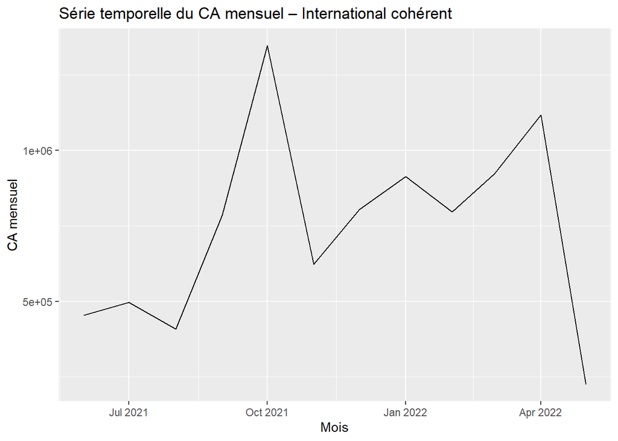

```r
intl_monthly <- InternationalSaleReport_coherentD %>%
  group_by(Months) %>%
  summarise(ca_total = sum(GROSS.AMT, na.rm = TRUE), .groups = "drop") %>%
  arrange(Months)

gg_intl_month <- ggplot(intl_monthly, aes(x = Months, y = ca_total)) +
  geom_line(color = "black") +
  labs(
    title = "Série temporelle du CA mensuel – International cohérent",
    x = "Mois",
    y = "CA mensuel"
  )

gg_intl_month
```

```r
ggplotly(gg_intl_month)
```

[interactive chart not shown]

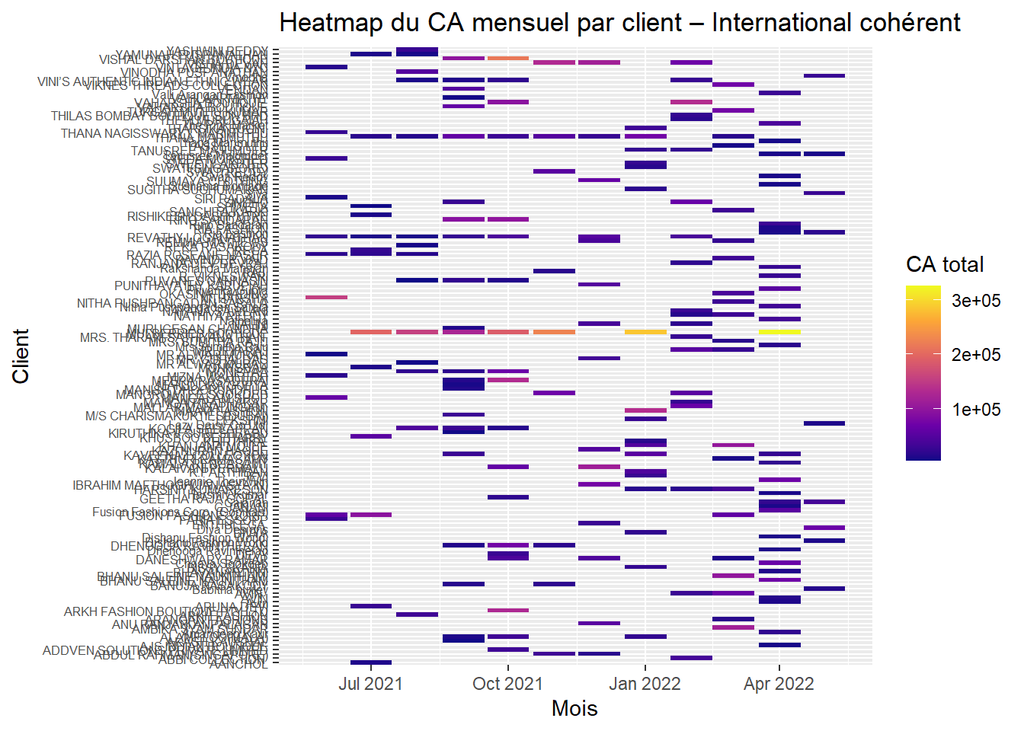

```r
## ===============================================
## Heatmap CA mensuel par client – International
## ===============================================


intl_month_client <- InternationalSaleReport_coherentD %>%
  mutate(mois = floor_date(date, unit = "month")) %>%
  group_by(CUSTOMER, mois) %>%
  summarise(ca_total = sum(`GROSS.AMT`, na.rm = TRUE), .groups = "drop")


gg_intl_heat <- ggplot(intl_month_client, aes(x = mois, y = CUSTOMER, fill = ca_total)) +
  geom_tile() +
  scale_fill_viridis_c(option = "C") +
  labs(
    title = "Heatmap du CA mensuel par client – International cohérent",
    x = "Mois", y = "Client", fill = "CA total"
  ) +
  theme(axis.text.y = element_text(size = 6))


gg_intl_heat
```

```r
ggplotly(gg_intl_heat)
```

[interactive chart not shown]

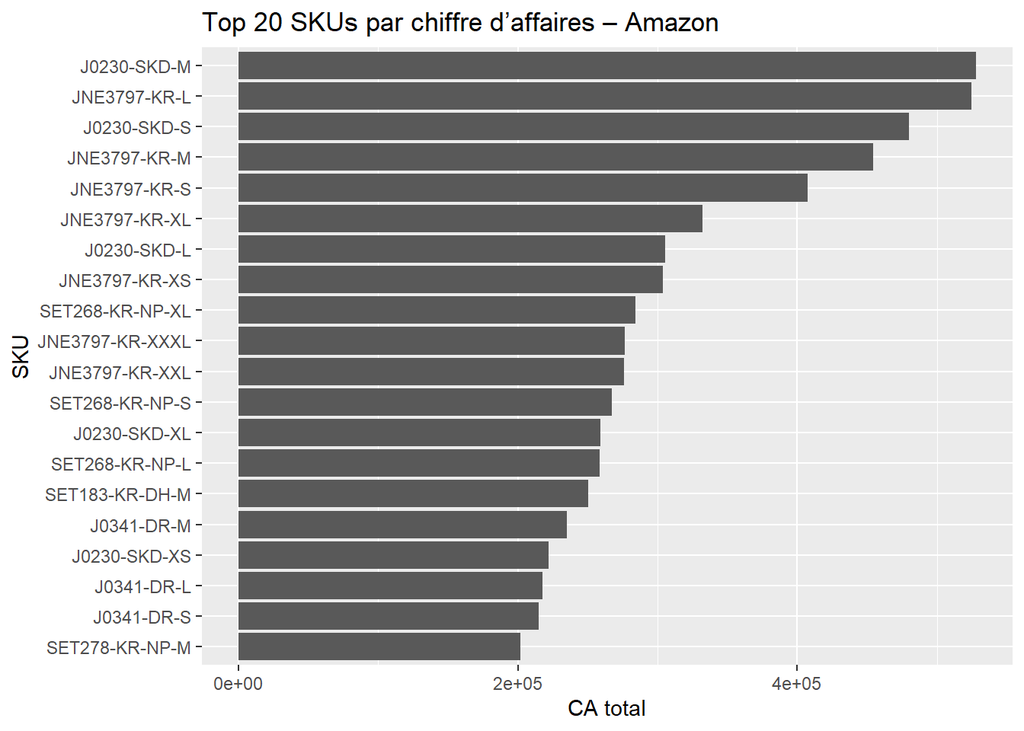

```r
## =============================
## Top 20 SKUs par CA – Amazon
## =============================


amazon_top_sku <- AmazonSaleReport %>%
  group_by(SKU) %>%
  summarise(ca_total = sum(Amount, na.rm = TRUE), .groups = "drop") %>%
  arrange(desc(ca_total)) %>%
  slice_head(n = 20)


gg_top_sku <- ggplot(amazon_top_sku,
                     aes(x = reorder(SKU, ca_total), y = ca_total)) +
  geom_col() +
  coord_flip() +
  labs(title = "Top 20 SKUs par chiffre d’affaires – Amazon",
       x = "SKU",
       y = "CA total")

gg_top_sku
```

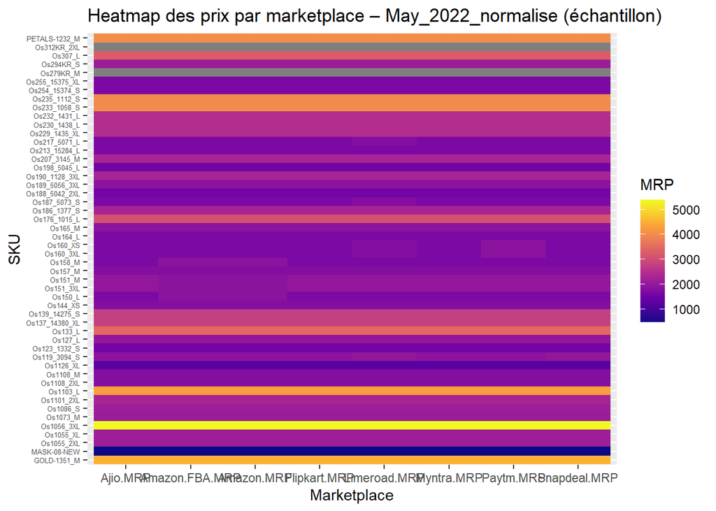

```r
## =============================================================
## Heatmap des prix par marketplace – May & PLM (échantillon)
## =============================================================


# On échantillonne quelques SKUs pour avoir une heatmap lisible

set.seed(123)
may_sample <- May_2022_normalise %>%
  sample_n(size = 50)


may_prices_long <- may_sample %>%
  select(Sku, Ajio.MRP, Amazon.FBA.MRP, Amazon.MRP, Flipkart.MRP,
         Limeroad.MRP, Myntra.MRP, Paytm.MRP, Snapdeal.MRP) %>%
  pivot_longer(cols = -Sku,
               names_to = "Marketplace",
               values_to = "MRP")


gg_may_heat <- ggplot(may_prices_long,
                      aes(x = Marketplace, y = Sku, fill = MRP)) +
  geom_tile() +
  scale_fill_viridis_c(option = "C") +
  labs(title = "Heatmap des prix par marketplace – May_2022_normalise (échantillon)",
       x = "Marketplace",
       y = "SKU",
       fill = "MRP") +
  theme(axis.text.y = element_text(size = 5))

gg_may_heat
```

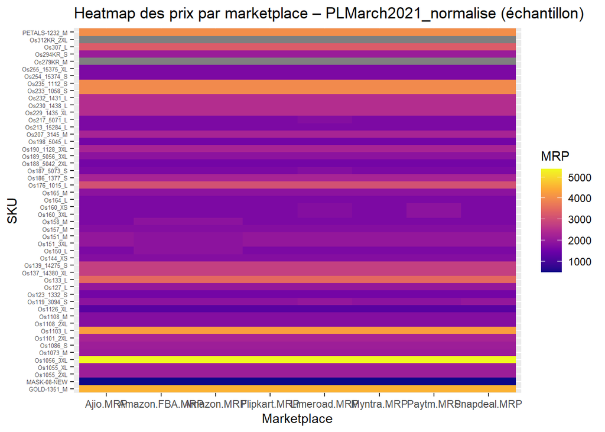

```r
## Même chose pour PLMarch2021_normalise

set.seed(123)
plm_sample <- PLMarch2021_normalise %>% sample_n(size = 50)

plm_prices_long <- plm_sample %>%
  select(Sku, Ajio.MRP, Amazon.FBA.MRP, Amazon.MRP, Flipkart.MRP,
         Limeroad.MRP, Myntra.MRP, Paytm.MRP, Snapdeal.MRP) %>%
  pivot_longer(cols = -Sku,
               names_to = "Marketplace",
               values_to = "MRP")


gg_plm_heat <- ggplot(plm_prices_long,
                      aes(x = Marketplace, y = Sku, fill = MRP)) +
  geom_tile() +
  scale_fill_viridis_c(option = "C") +
  labs(title = "Heatmap des prix par marketplace – PLMarch2021_normalise (échantillon)",
       x = "Marketplace",
       y = "SKU",
       fill = "MRP") +
  theme(axis.text.y = element_text(size = 5))

gg_plm_heat
```

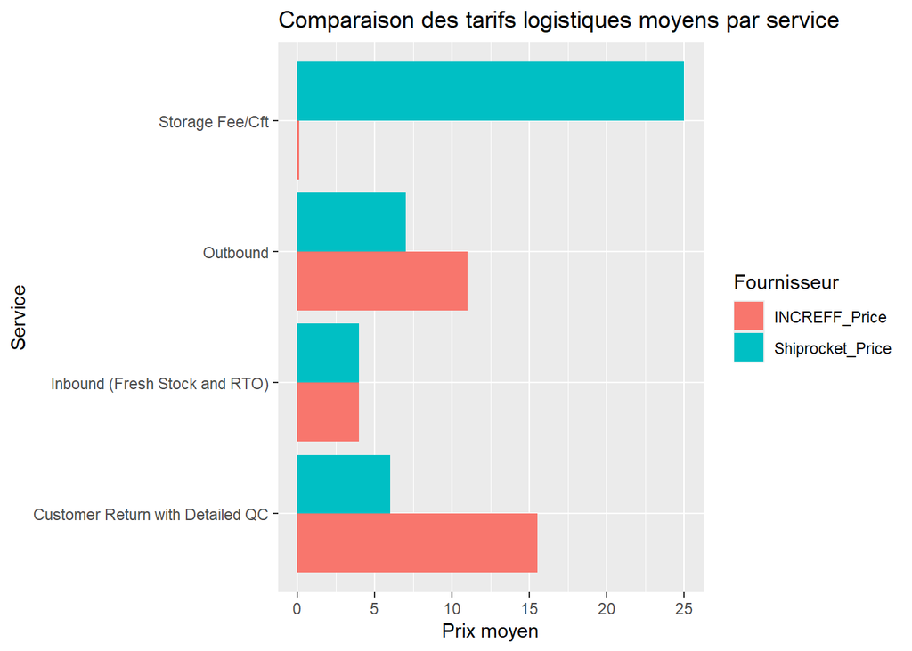

```r
## ==================================================================
## Comparaison des tarifs logistiques moyens – INCREFF vs Shiprocket
## ==================================================================


cloud_prices_long <- Cloud_clean %>%
  group_by(Service) %>%
  summarise(
    Shiprocket_Price_mean = mean(Shiprocket_Price, na.rm = TRUE),
    INCREFF_Price_mean    = mean(INCREFF_Price, na.rm = TRUE),
    .groups = "drop"
  ) %>%
  pivot_longer(cols = ends_with("_mean"),
               names_to = "Fournisseur",
               values_to = "Prix_moyen") %>%
  mutate(Fournisseur = if_else(str_detect(Fournisseur, "INCREFF"),
                               "INCREFF_Price", "Shiprocket_Price"))


gg_cloud_bar <- ggplot(cloud_prices_long,
                       aes(x = Prix_moyen, y = Service, fill = Fournisseur)) +
  geom_col(position = "dodge") +
  labs(title = "Comparaison des tarifs logistiques moyens par service",
       x = "Prix moyen",
       y = "Service")

gg_cloud_bar
```

**INTERPRETATIONS**

**1. Séries temporelles du chiffre d’affaires**

**Observation générale**

Le CA quotidien Amazon présente un niveau élevé et relativement stable, avec des fluctuations journalières marquées et quelques pics nets (fin avril–début mai, début juin).

Le CA quotidien International cohérent est beaucoup plus volatil, alternant jours de très faible activité et pics ponctuels importants.

Le CA mensuel International cohérent révèle une dynamique plus lisible, avec un pic majeur à l’automne (octobre), une baisse en fin d’année, puis une reprise partielle début 2022.

**Relations**

Les pics quotidiens observés à l’international se concentrent sur certains mois, ce qui explique leur amplification dans la série mensuelle.

Amazon montre une activité continue, suggérant un flux de commandes régulier, contrairement à l’international davantage piloté par des commandes groupées.

**Points d’attention**

L’analyse quotidienne internationale est bruitée : elle peut masquer les tendances structurelles.

Les pics extrêmes peuvent correspondre à gros clients, contrats spécifiques ou effets logistiques, et non à une tendance commerciale durable.

**Conclusion analytique**

La temporalité pertinente dépend du canal :

- Quotidien pour Amazon (pilotage opérationnel).
- Mensuel pour l’international (lecture stratégique et prévisionnelle).

**2. Heatmap du CA mensuel par client – International cohérent**

**Observation générale**

La heatmap met en évidence une forte hétérogénéité entre clients.

Quelques clients concentrent des zones chaudes récurrentes (CA élevé sur plusieurs mois), tandis que la majorité apparaît de manière ponctuelle.

**Relations**

Les mois de CA global élevé correspondent à l’activité de clients dominants.

Certains clients montrent une saisonnalité marquée, actifs uniquement sur 1–2 périodes.

**Points d’attention**

Forte dépendance à un nombre réduit de clients.

Risque commercial en cas de perte ou de baisse d’activité de ces clients clés.

**Conclusion analytique**

La structure internationale suit clairement une logique Pareto (80/20) : un petit noyau de clients génère l’essentiel du CA, ce qui justifie une segmentation client prioritaire.

**3. Top 20 SKUs par chiffre d’affaires – Amazon**

**Observation générale**

Le CA est fortement concentré sur quelques SKUs, avec une décroissance rapide après les premiers rangs.

Les variantes de taille (S, M, L, XL) d’un même modèle figurent souvent ensemble.

**Relations**

Les modèles best-sellers sont déclinés efficacement, ce qui amplifie leur contribution au CA.

Le succès dépend plus du modèle que de la taille individuelle.

**Points d’attention**

Dépendance excessive à un nombre restreint de références.

Risque de rupture de stock ou d’impact fort en cas de problème logistique sur ces SKUs.

**Conclusion analytique**

Ces SKUs doivent être :

- Prioritaires en stock,
- Suivis en pricing,
- Utilisés comme références de prévision.

**4. Heatmaps des prix par marketplace : May_2022_normalise & PLMarch2021_normalise**

**Observation générale**

Les niveaux de prix par SKU sont très homogènes entre marketplaces.

Les écarts visuels sont faibles et stables dans le temps.

**Relations**

Forte cohérence tarifaire multicanale, confirmée par les corrélations proches de 1 observées précédemment.

La normalisation des prix est respectée entre plateformes.

**Points d’attention**

La cohérence visuelle n’implique pas une cohérence de marge (commissions, logistique différentes).

Les écarts faibles peuvent masquer des effets de coût non visibles ici.

**Conclusion analytique**

La stratégie de pricing est maîtrisée, ce qui facilite :

- le pilotage multicanal,
- la comparaison de performance par marketplace.

**5. Comparaison des tarifs logistiques moyens par service**

**Observation générale**

Les écarts entre Shiprocket et INCREF varient fortement selon le service.

INCREF est nettement plus cher sur les retours clients avec QC détaillé.

Shiprocket affiche un coût élevé sur le Storage Fee/Cft.

**Relations**

Chaque prestataire est compétitif sur des segments différents.

Les différences de coûts expliquent potentiellement certains écarts de rentabilité.

**Points d’attention**

Un choix unique de prestataire n’est pas optimal économiquement.

Les services à forte fréquence (Outbound, Retours) doivent être surveillés en priorité.

**Conclusion analytique**

Une stratégie logistique hybride est recommandée :

- choisir le prestataire par type de service, et non globalement.

**Conclusion transversale**

Les visualisations confirment :

- une forte concentration du CA (clients & produits),
- une stabilité opérationnelle Amazon,
- une volatilité maîtrisable à l’international,
- une cohérence tarifaire solide,
- et des leviers clairs d’optimisation logistique.

**4.2. CONSTRUCTION DU DASHBOARD (SHINY)**

```r
## ==========================
## App Shiny – Dashboard EDA
## ==========================


ui <- fluidPage(
  titlePanel("Dashboard ventes & logistique"),

  sidebarLayout(
    sidebarPanel(
      dateRangeInput("date_range", "Période :",
                     start = min(AmazonSaleReport$Date),
                     end   = max(AmazonSaleReport$Date)),
      selectInput("market_view", "Marketplace catalogue :",
                  choices = c("May_2022_normalise", "PLMarch2021_normalise")),
      width = 3
    ),

    mainPanel(
      tabsetPanel(
        tabPanel("CA quotidien Amazon", plotlyOutput("plot_amazon_ts")),
        tabPanel("CA quotidien International", plotlyOutput("plot_intl_ts")),
        tabPanel("Top SKUs Amazon", plotOutput("plot_top_sku")),
        tabPanel("Heatmap CA client (Intl.)", plotOutput("plot_intl_heat")),
        tabPanel("Prix catalogue", plotOutput("plot_catalog_heat")),
        tabPanel("Logistique", plotOutput("plot_cloud_bar"))
      )
    )
  )
)


server <- function(input, output, session){

  # Filtrage des périodes
  amazon_daily_reac <- reactive({
    amazon_daily %>%
      filter(Date >= input$date_range[1],
             Date <= input$date_range[2])
  })

  intl_daily_reac <- reactive({
    intl_daily %>%
      filter(date >= input$date_range[1],
             date <= input$date_range[2])
  })

  output$plot_amazon_ts <- renderPlotly({
    gg <- ggplot(amazon_daily_reac(), aes(x = Date, y = ca_total)) +
      geom_line() +
      labs(title = "CA quotidien – Amazon",
           x = "Date", y = "CA quotidien")
    ggplotly(gg)
  })

  output$plot_intl_ts <- renderPlotly({
    gg <- ggplot(intl_daily_reac(), aes(x = date, y = ca_total)) +
      geom_line() +
      labs(title = "CA quotidien – International cohérent",
           x = "Date", y = "CA quotidien")
    ggplotly(gg)
  })

  output$plot_top_sku <- renderPlot({
    gg_top_sku
  })

  output$plot_intl_heat <- renderPlot({
    gg_intl_heat
  })

  output$plot_catalog_heat <- renderPlot({
    if(input$market_view == "May_2022_normalise"){
      gg_may_heat
    } else {
      gg_plm_heat
    }
  })

  output$plot_cloud_bar <- renderPlot({
    gg_cloud_bar
  })
}

# Pour lancer le dashboard :
# shinyApp(ui, server)
```

**VISUALISATION DU DASHBORAD PAR LE CORRECTEUR**

Un dashboard interactif développé avec **Shiny** a été conçu afin de prolonger l’analyse exploratoire des données et de faciliter l’exploration dynamique des indicateurs clés de ventes et de logistique.

Le dashboard **n’est pas exécuté dans ce document HTML**, mais peut être lancé localement à partir du projet R fourni.

**Script du dashboard :**

- Fichier : `app.R`
- Section : **4.2. CONSTRUCTION DU DASHBOARD (SHINY)**

**Commande pour lancer l’application :**

```r
shiny::runApp()
```

**VISUALISATION DU DASHBORAD PAR LE CORRECTEUR - INTÉGRATION DANS LE RAPPORT RMD**

Cette section présente des captures du dashboard Shiny développé afin d’illustrer son contenu et ses principales fonctionnalités.

Le dashboard complet peut être lancé localement via le fichier `app.R` (voir section précédente).

**Exemple 1 — CA quotidien Amazon**

### Chiffre d’affaires quotidien – Amazon

La figure suivante présente l’évolution du chiffre d’affaires quotidien sur le canal Amazon, avec possibilité de filtrage temporel dans le dashboard.

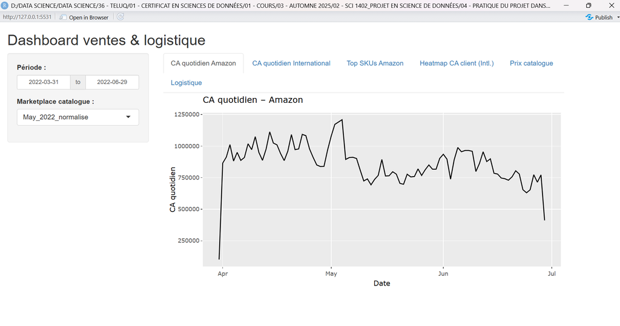

**Exemple 2 — CA quotidien International**

### Chiffre d’affaires quotidien – International

Cette vue permet d’analyser la volatilité des ventes internationales et d’identifier des pics ponctuels de chiffre d’affaires.

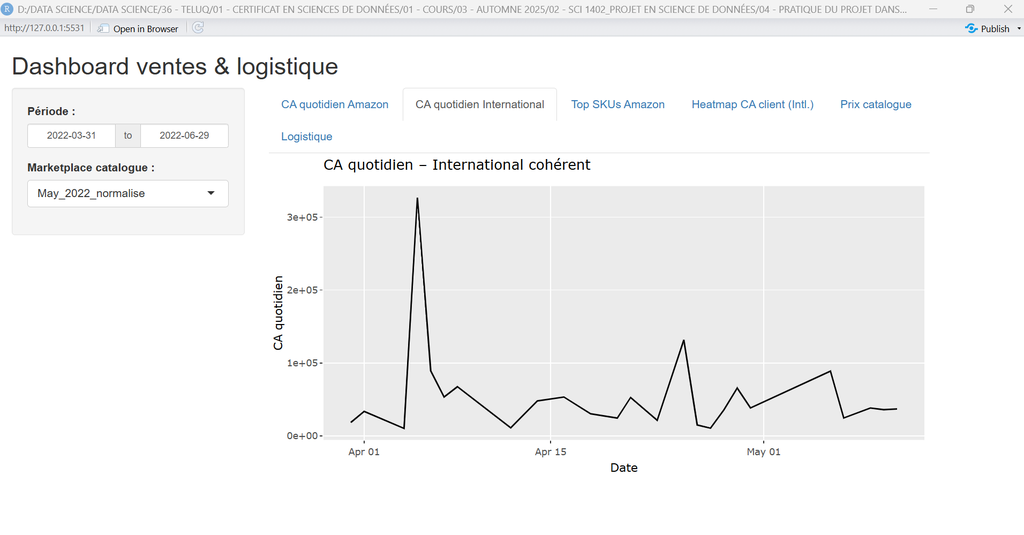

**Exemple 3 — Top SKUs**

### Top SKUs par chiffre d’affaires

Le dashboard permet d’identifier rapidement les produits les plus performants en termes de chiffre d’affaires cumulé.

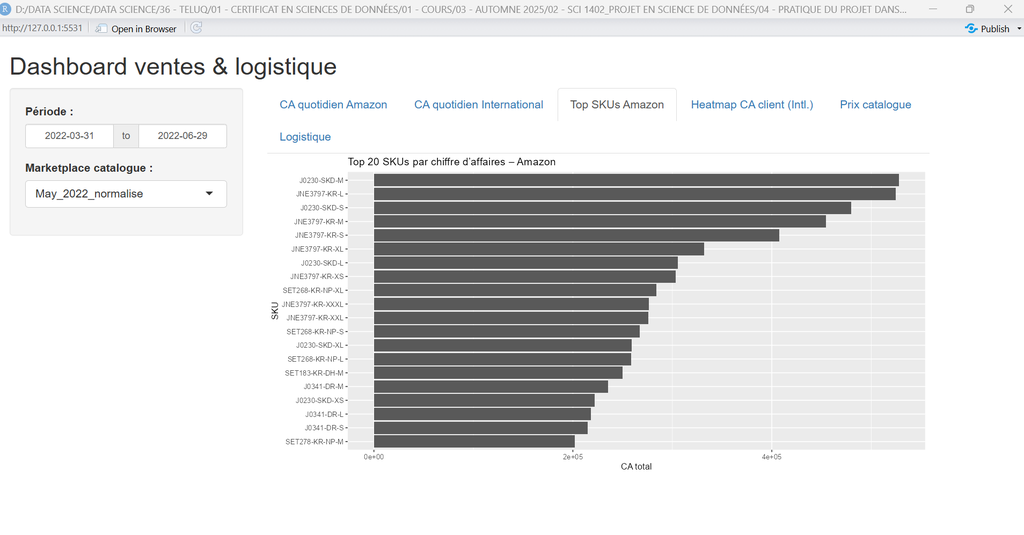

**Exemple 4 — Heatmap clients**

### Heatmap du chiffre d’affaires mensuel par client

Cette visualisation met en évidence l’hétérogénéité des contributions clients dans le temps.

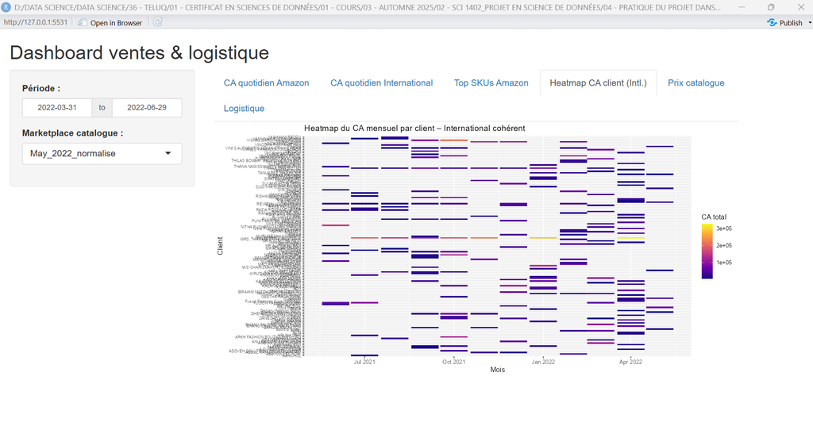

**Exemple 5 — Prix catalogue_May2022**

### Comparaison des prix catalogue par marketplace

Le dashboard permet de comparer les niveaux de prix par marketplace et d’identifier les écarts significatifs.

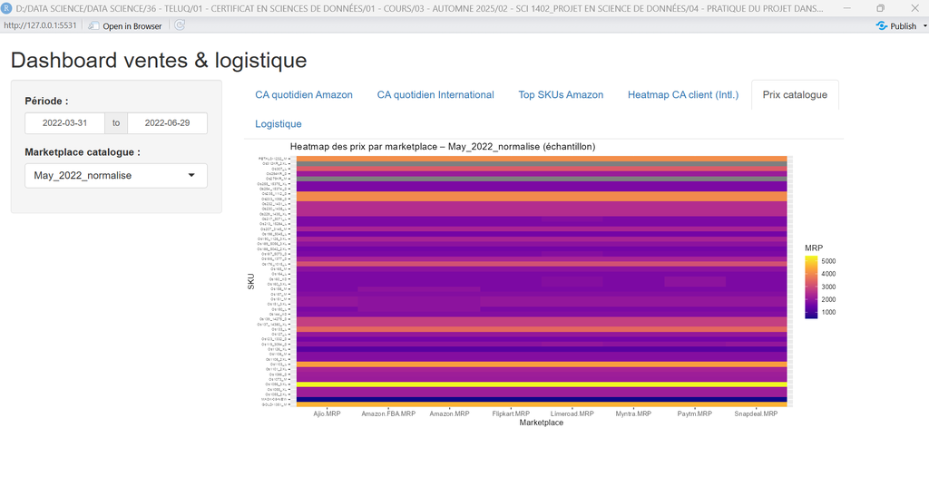

**Exemple 6 — Prix catalogue_PLMarch2021**

### Comparaison des prix catalogue par marketplace

Le dashboard permet de comparer les niveaux de prix par marketplace et d’identifier les écarts significatifs.

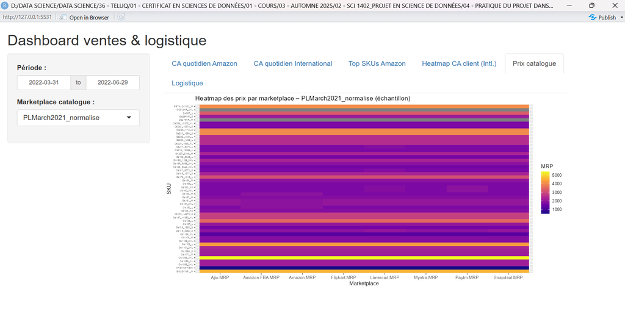

**Exemple 7 — Logistique**

### Comparaison des coûts logistiques

Cette vue compare les coûts moyens par service et par prestataire logistique.

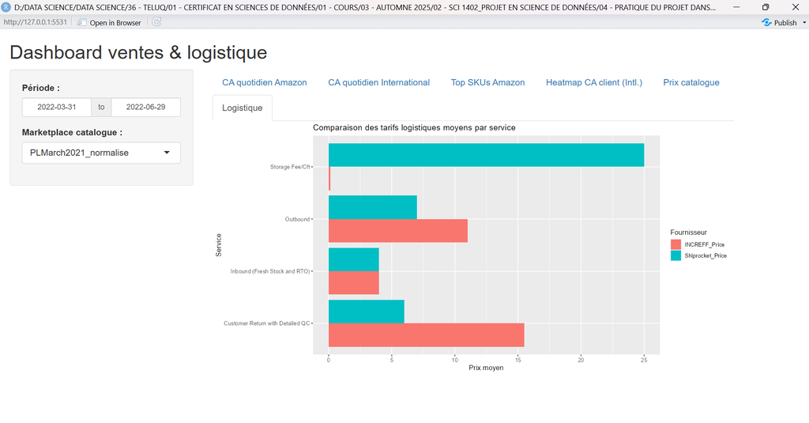

**Conclusion**

Le dashboard Shiny complète l’analyse exploratoire en offrant :

- un **suivi dynamique du chiffre d’affaires** (Amazon & International),
- l’**identification des produits les plus performants**,
- une **analyse de la concentration des ventes par client**,
- la **comparaison des prix catalogue** par marketplace,
- une **analyse comparative des coûts logistiques**.

Il constitue un **outil d’aide à la décision** permettant d’explorer les données de manière interactive

au-delà des visualisations statiques présentées dans le rapport.

**5. ANALYSE STATISTIQUE**

Cette étape vise à valider (ou invalider) les hypothèses H1–H4 definies plus haut lors de presentation du projet à l’aide de tests statistiques rigoureux.

Elle permet de passer d’une analyse descriptive à une analyse inférentielle, indispensable pour formuler des conclusions robustes.

**Contenu prévu :**

**Tests d’hypothèses**

Chaque hypothèse sera testée par une méthode appropriée :

**H1 – Test de saisonnalité des ventes**

Les ventes suivent une forte saisonnalité.

**Méthodes :**

- Décomposition STL des séries temporelles.
- Tests d’autocorrélations (ACF / PACF).
- Test de Kruskal-Wallis ou ANOVA par mois.

**Résultat attendu :**

✔ Déterminer si certains mois génèrent significativement plus de ventes.

**H2 – Loi de Pareto (80/20) sur les produits**

20% des produits génèrent 80% du CA.

**Méthodes :**

- Analyse cumulative du CA.
- Courbe de Lorenz et coefficient de Gini.
- Test de concentration.

**Résultat attendu :**

✔ Quantifier la contribution réelle des top produits.

**H3 – Segmentation des clients selon fréquence & panier**

Les clients peuvent être répartis en groupes distincts.

**Méthodes :**

Clustering hiérarchique ou K-means sur :

- fréquence
- montant total
- panier moyen

Analyse de variance entre clusters.

**Résultat attendu :**

✔ Création de segments actionnables pour CRM.

**H4 – Impact des remises / promotions sur les ventes**

Les promotions influencent significativement les volumes.

**Méthodes :**

- Régressions linéaires (modèle : quantité ~ remise).
- Tests t / Wilcoxon entre périodes avec et sans promotion.
- Elasticité prix → quantité.

**Résultat attendu :**

✔ Estimation quantitative de l’effet promotionnel.

**Objectifs de l’analyse statistique :**

- Valider les observations exploratoires.
- Transformer les intuitions en preuves.
- Préparer le terrain aux modèles de machine learning.

**H1 – Saisonnalité des ventes**

Afin d’évaluer la présence d’une saisonnalité des ventes (H1), une analyse statistique a été menée sur le chiffre d’affaires quotidien Amazon.

Un test de normalité (Shapiro-Wilk) réalisé sur un sous-échantillon indique une déviation à la normalité, ce qui justifie le recours à un test non paramétrique.

Le test de Kruskal-Wallis met en évidence des différences significatives entre les mois, suggérant une saisonnalité des ventes.

Cette observation est confirmée par la décomposition STL de la série temporelle, qui fait apparaître une composante saisonnière marquée.

```r
## =========================================================
## H1 : Saisonnalité des ventes – Amazon
## =========================================================

library(dplyr)
library(lubridate)

# Création de la variable mois
amazon_daily <- amazon_daily %>%
  mutate(month = factor(month(Date, label = TRUE)))

# ---------------------------------------------------------
# Test de normalité (Shapiro-Wilk sur sous-échantillon)
# ---------------------------------------------------------
n <- length(amazon_daily$ca_total)
sample_size <- min(500, n)

set.seed(123)
shapiro.test(sample(amazon_daily$ca_total, sample_size))
```

```
##
##  Shapiro-Wilk normality test
##
## data:  sample(amazon_daily$ca_total, sample_size)
## W = 0.91337, p-value = 1.531e-05
```

```r
# ---------------------------------------------------------
# ANOVA (si normalité acceptable)
# ---------------------------------------------------------
anova_res <- aov(ca_total ~ month, data = amazon_daily)
summary(anova_res)
```

```
##             Df    Sum Sq   Mean Sq F value  Pr(>F)
## month        3 9.667e+11 3.222e+11   22.59 6.6e-11 ***
## Residuals   87 1.241e+12 1.426e+10
## ---
## Signif. codes:  0 '***' 0.001 '**' 0.01 '*' 0.05 '.' 0.1 ' ' 1
```

```r
# ---------------------------------------------------------
# Alternative non paramétrique (si non-normalité)
# ---------------------------------------------------------
kruskal.test(ca_total ~ month, data = amazon_daily)
```

```
##
##  Kruskal-Wallis rank sum test
##
## data:  ca_total by month
## Kruskal-Wallis chi-squared = 28.519, df = 3, p-value = 2.826e-06
```

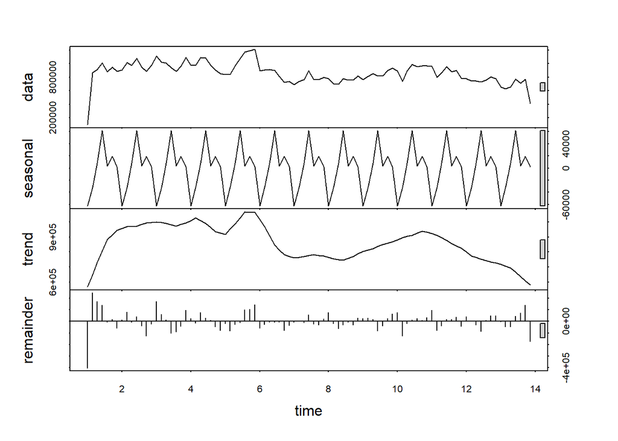

```r
# ---------------------------------------------------------
# Décomposition temporelle (STL)
# ---------------------------------------------------------
amazon_ts <- ts(amazon_daily$ca_total, frequency = 7)  # hebdomadaire
amazon_stl <- stl(amazon_ts, s.window = "periodic")

plot(amazon_stl)
```

**Interpretation**

- Le test de Shapiro–Wilk est significatif (p-value ≈ 1.5e-05), indiquant que le chiffre d’affaires quotidien ne suit pas une loi normale.
- Malgré cette non-normalité, l’ANOVA montre un effet très significatif du mois sur le CA (F = 22.59, p < 0.001).
- Le test non paramétrique de Kruskal–Wallis confirme ce résultat (χ² = 28.52, p < 0.001), validant la robustesse de la conclusion.
- Il existe donc une différence significative de CA entre les mois, suggérant une saisonnalité marquée.
- La décomposition STL met en évidence une composante saisonnière régulière, compatible avec un cycle hebdomadaire.
- La tendance montre une phase de hausse suivie d’un ralentissement progressif.
- La composante résiduelle reste globalement faible, indiquant un bon ajustement du modèle.
- Ces résultats confirment l’hypothèse H1 : présence d’une saisonnalité significative des ventes Amazon.

**H2 – Pareto 80/20 sur les produits**

L’hypothèse H2 vise à vérifier l’existence d’un effet de type Pareto (80/20) dans la répartition du chiffre d’affaires par produit (SKU).

Selon ce principe, une part réduite des produits génèrerait la majorité du chiffre d’affaires total. Pour tester cette hypothèse, le chiffre d’affaires a été agrégé par SKU puis ordonné de manière décroissante.

La courbe de Lorenz permet de visualiser la concentration du chiffre d’affaires entre les produits. Un écart marqué par rapport à la diagonale d’égalité indiquerait une forte concentration.

Le coefficient de Gini est également calculé afin de quantifier le degré d’inégalité de cette répartition.

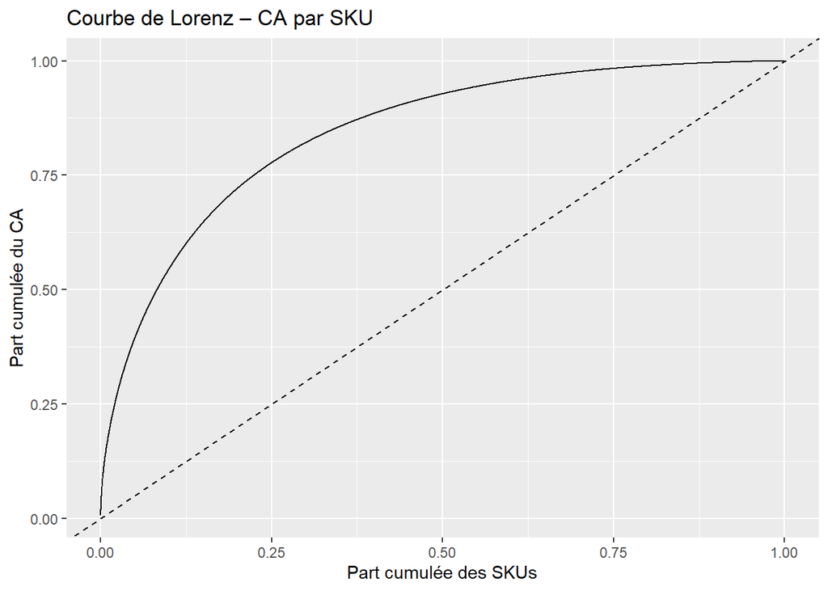

```r
## ============================
## H2 : Pareto 80/20 produits
## ============================

amazon_sku_ca <- AmazonSaleReport %>%
  group_by(SKU) %>%
  summarise(ca_total = sum(Amount, na.rm = TRUE), .groups = "drop") %>%
  arrange(desc(ca_total)) %>%
  mutate(
    part_ca = ca_total / sum(ca_total),
    part_ca_cum = cumsum(part_ca),
    part_sku_cum = row_number() / n()
  )

# Courbe de Lorenz
gg_pareto <- ggplot(amazon_sku_ca,
                    aes(x = part_sku_cum, y = part_ca_cum)) +
  geom_line() +
  geom_abline(linetype = "dashed") +
  labs(title = "Courbe de Lorenz – CA par SKU",
       x = "Part cumulée des SKUs",
       y = "Part cumulée du CA")

gg_pareto
```

```r
# Coefficient de Gini
gini_ca <- Gini(amazon_sku_ca$ca_total)
gini_ca
```

```
## [1] 0.6867953
```

**Interpretation**

- La courbe de Lorenz du chiffre d’affaires par SKU s’écarte fortement de la diagonale d’égalité, indiquant une répartition très inégale du CA entre les produits.
- Une proportion réduite de SKUs concentre une part majeure du chiffre d’affaires total.
- Cette concentration est quantifiée par un coefficient de Gini élevé (G ≈ 0,69), révélant une forte inégalité de contribution des produits.
- Le résultat est compatible avec le principe de Pareto (80/20), selon lequel une minorité de références génère l’essentiel du CA.
- La structure observée traduit une dépendance commerciale importante à un nombre limité de produits clés.
- Cette configuration implique un risque opérationnel accru en cas de rupture ou de baisse de performance de ces SKUs dominants.
- Elle met également en évidence des leviers potentiels d’optimisation du portefeuille produits.
- Ces résultats confirment l’hypothèse H2 : forte concentration du chiffre d’affaires sur un sous-ensemble restreint de produits.

**H3 – Segmentation clients (RFM simplifié)**

Cette partie vise à segmenter les clients internationaux à partir d’une approche RFM (Récence, Fréquence, Montant).

L’objectif est d’identifier des profils de clients distincts selon leur comportement d’achat et leur contribution au chiffre d’affaires.

Après normalisation des variables RFM, une classification k-means a été appliquée afin de regrouper les clients en clusters homogènes.

Cette segmentation permet d’éclairer les stratégies de fidélisation, de réactivation et de priorisation commerciale.

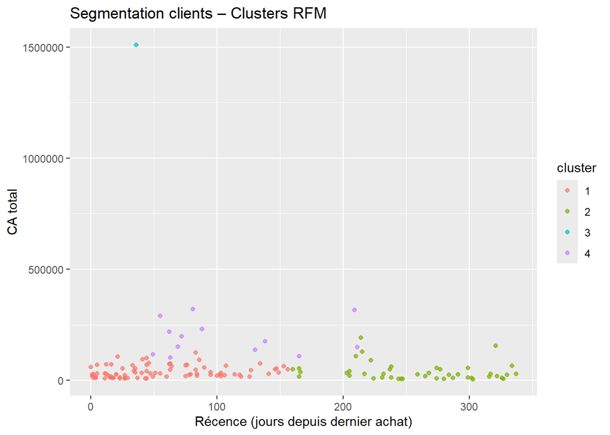

```r
## =============================================================
## H3 : Segmentation clients (RFM simplifié)
## Base : InternationalSaleReport_coherentD (date standardisée)
## =============================================================


# 1) Point de référence (dernière date disponible)
today_date <- max(InternationalSaleReport_coherentD$date, na.rm = TRUE)


# 2) Calcul RFM par client
rfm_data <- InternationalSaleReport_coherentD %>%
  group_by(CUSTOMER) %>%
  summarise(
    recency   = as.numeric(today_date - max(date, na.rm = TRUE)),   # jours depuis dernier achat
    frequency = n(),                                                # nb de lignes (transactions)
    monetary  = sum(GROSS.AMT, na.rm = TRUE),                       # CA total
    .groups = "drop"
  )


# 3) Normalisation
rfm_scaled <- rfm_data %>%
  select(recency, frequency, monetary) %>%
  scale()


# 4) Clustering k-means
set.seed(123)
k_opt <- 4  # à ajuster avec silhouette / elbow
rfm_kmeans <- kmeans(rfm_scaled, centers = k_opt, nstart = 25)

rfm_data$cluster <- factor(rfm_kmeans$cluster)


# 5) Visualisation 2D (Recency vs Monetary)
gg_rfm_clusters <- ggplot(rfm_data, aes(x = recency, y = monetary, color = cluster)) +
  geom_point(alpha = 0.7) +
  labs(
    title = "Segmentation clients – Clusters RFM",
    x = "Récence (jours depuis dernier achat)",
    y = "CA total"
  )

gg_rfm_clusters
```

**Interpretation**

- La segmentation RFM met en évidence quatre clusters de clients présentant des comportements d’achat distincts.
- Un premier cluster regroupe des clients récents et à faible CA, correspondant majoritairement à des acheteurs occasionnels.
- Un second cluster est composé de clients anciens (forte récence) avec un faible montant, indiquant un risque élevé de churn.
- Un troisième cluster concentre des clients à très forte contribution au chiffre d’affaires, malgré une fréquence modérée.
- Ce groupe représente les clients stratégiques à forte valeur, à prioriser pour la fidélisation.
- Le dernier cluster correspond à des clients intermédiaires, combinant récence moyenne et CA modéré.
- La séparation nette entre clusters confirme la pertinence de la segmentation k-means.
- Ces résultats valident l’hypothèse H3 : existence de profils clients distincts basés sur le comportement RFM.

**H4 – Impact des promotions / remises**

Cette hypothèse vise à analyser l’impact des promotions tarifaires sur les volumes de ventes.

Une remise est approximée par le taux de réduction entre le prix catalogue (MRP.Old) et le prix effectif pratiqué.

L’analyse compare les quantités vendues avec et sans promotion, puis évalue la relation entre le taux de remise et la quantité vendue.

L’objectif est de déterminer si les promotions constituent un levier significatif d’augmentation des ventes.

Supposons que la remise soit discount = 1 - prix_effectif / MRP.Old.

On illustre sur May_2022_normalise (adapter selon la logique de prix effectif).

```r
## ==================================
## H4 : Impact des remises sur ventes
## ==================================


may_promo <- May_2022_normalise %>%
  mutate(
    # Exemple : Ajio comme prix pratiqué
    discount_rate = 1 - Ajio.MRP / MRP.Old,
    promo_flag    = discount_rate > 0
  ) %>%
  # suppose qu'on a la quantité vendue "TP"
  filter(!is.na(TP))


# Comparaison des quantités avec/sans promo
t.test(TP ~ promo_flag, data = may_promo)
```

```
##
##  Welch Two Sample t-test
##
## data:  TP by promo_flag
## t = -0.45242, df = 22.96, p-value = 0.6552
## alternative hypothesis: true difference in means between group FALSE and group TRUE is not equal to 0
## 95 percent confidence interval:
##  -111.03476   71.18672
## sample estimates:
## mean in group FALSE  mean in group TRUE
##            572.4673            592.3913
```

```r
# Régression linéaire : quantité ~ remise
lm_promo <- lm(TP ~ discount_rate, data = may_promo)
summary(lm_promo)
```

```
##
## Call:
## lm(formula = TP ~ discount_rate, data = may_promo)
##
## Residuals:
##     Min      1Q  Median      3Q     Max
## -481.49 -166.49  -78.94  113.51  882.30
##
## Coefficients:
##               Estimate Std. Error t value Pr(>|t|)
## (Intercept)    581.493      7.059  82.373   <2e-16 ***
## discount_rate  570.682    207.324   2.753    0.006 **
## ---
## Signif. codes:  0 '***' 0.001 '**' 0.01 '*' 0.05 '.' 0.1 ' ' 1
##
## Residual standard error: 227.2 on 1291 degrees of freedom
##   (31 observations deleted due to missingness)
## Multiple R-squared:  0.005835,   Adjusted R-squared:  0.005065
## F-statistic: 7.577 on 1 and 1291 DF,  p-value: 0.005995
```

**Interpretation**

- Le test t de Welch ne met pas en évidence de différence significative des quantités moyennes vendues entre les périodes avec et sans promotion (p-value = 0.655).
- Les quantités moyennes sont légèrement plus élevées en période promotionnelle, mais cet écart n’est pas statistiquement significatif.
- La régression linéaire montre toutefois un effet positif et significatif du taux de remise sur la quantité vendue (β ≈ 571, p ≈ 0.006).
- Cela suggère qu’une augmentation du niveau de remise est associée à une hausse des volumes, toutes choses égales par ailleurs.
- Néanmoins, le faible R² (~0.6 %) indique que la remise explique une part très limitée de la variabilité des ventes.
- Les promotions ont donc un effet marginal mais réel, insuffisant à elles seules pour piloter la performance commerciale.
- D’autres facteurs (saisonnalité, notoriété produit, disponibilité, clientèle) semblent jouer un rôle prépondérant.
- Ces résultats conduisent à une validation partielle de l’hypothèse H4 : l’impact des promotions existe, mais reste modéré.

**Conclusion globale – Synthèse des hypothèses H1 à H4**

L’analyse statistique menée sur les données de ventes a permis de valider plusieurs mécanismes clés structurant la performance commerciale.

Tout d’abord, les résultats de l’hypothèse **H1** mettent en évidence une **saisonnalité significative des ventes,** avec des variations marquées du chiffre d’affaires selon les périodes, confirmées par des tests statistiques robustes et une décomposition temporelle claire.

L’étude de l’hypothèse **H2** révèle ensuite une **forte concentration du chiffre d’affaires sur un nombre restreint de produits,** conforme au principe de Pareto 80/20. La courbe de Lorenz et un coefficient de Gini élevé soulignent une dépendance importante à quelques SKU stratégiques, impliquant un risque commercial en cas de rupture ou de baisse de performance de ces produits clés.

L’hypothèse **H3** met en lumière une **segmentation client pertinente,** distinguant clairement plusieurs profils de clients selon leur récence, leur fréquence d’achat et leur contribution au chiffre d’affaires. Cette segmentation offre un cadre opérationnel solide pour des actions marketing différenciées et une meilleure allocation des ressources commerciales.

Enfin, l’analyse de l’hypothèse **H4** indique que les **promotions ont un effet positif mais limité sur les volumes de vente.** Si le taux de remise influence significativement les quantités vendues, son pouvoir explicatif reste faible, suggérant que les promotions doivent être combinées à d’autres leviers pour maximiser leur efficacité.

Dans l’ensemble, ces résultats fournissent une compréhension approfondie et complémentaire des dynamiques de ventes, et constituent une base analytique robuste pour orienter les décisions stratégiques en matière de gestion des produits, des clients et des politiques commerciales.

**6. MACHINE LEARNING**

Cette étape consiste à appliquer des modèles prédictifs et des algorithmes de segmentation permettant d’automatiser les analyses et d’extraire des insights plus complexes.

**Contenu prévu :**

**6.1. Modèles de prévision des ventes**

**Objectif :** prédire le CA futur, les quantités vendues, les flux logistiques.

**Méthodes :**

- ARIMA / SARIMA
- Prophet (Meta)
- Random Forest Regressor
- Gradient Boosting (XGBoost)

**Applications :**

- anticiper les ruptures de stock
- planifier la production
- prévoir les revenus

**6.2. Segmentation Client (Clustering)**

**Objectif :** identifier des groupes homogènes pour le marketing.

**Algorithmes :**

- K-means
- Clustering hiérarchique
- DBSCAN (si données irrégulières)

**Variables :**

- fréquence d’achat
- panier moyen
- valeur client (CLV)

**Sorties :** ✔ Segments exploitables pour campagnes ciblées.

**6.3. Classification des produits selon leur performance**

**Objectif :** classer automatiquement les produits :

- Best-sellers
- Produits stables
- Produits à faible rotation
- Produits risqués (fort retour, faible marge)

**Algorithmes :**

- Random Forest
- SVM
- Réseaux neuronaux simples

**Indicateurs étudiés :**

- ventes
- marge
- variation du prix
- logistique associée

**Sorties :** ✔ Aide à la décision pour le catalogue, les promotions, le stockage.

**6.1. Prévision des ventes (time series forecasting)**

**6.1.1. Modèle ARIMA sur le CA Amazon**

```r
## ============================
## Prévision CA Amazon – ARIMA
## ============================


amazon_ts <- ts(amazon_daily$ca_total,
                frequency = 7)  # 7 = hebdo ; 30 si mensuel approx.


fit_arima <- auto.arima(amazon_ts)
summary(fit_arima)
```

```
## Series: amazon_ts
## ARIMA(0,1,0)
##
## sigma^2 = 1.439e+10:  log likelihood = -1180.25
## AIC=2362.5   AICc=2362.54   BIC=2365
##
## Training set error measures:
##                    ME     RMSE      MAE        MPE     MAPE      MASE
## Training set 3406.029 119301.7 72821.74 -0.5151433 8.820098 0.6091517
##                     ACF1
## Training set -0.02922083
```

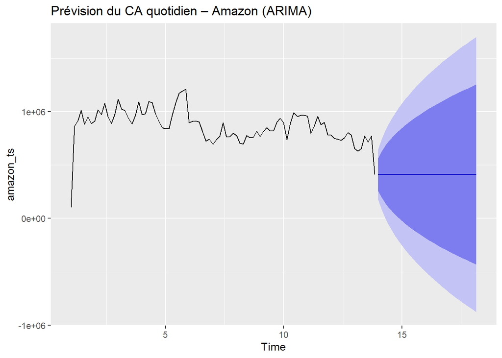

```r
forecast_arima <- forecast(fit_arima, h = 30)  # prévision 30 jours
autoplot(forecast_arima) +
  labs(title = "Prévision du CA quotidien – Amazon (ARIMA)")
```

**6.1.2. Modèle Prophet sur CA International**

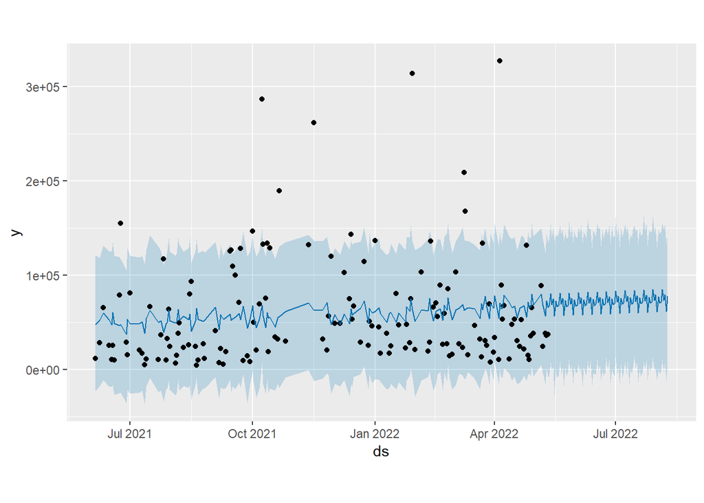

```r
## ============================================
## Prévision CA International – modèle Prophet
## ============================================

intl_prophet <- intl_daily %>%
  rename(ds = date, y = ca_total)


m_prophet <- prophet(intl_prophet)
future <- make_future_dataframe(m_prophet, periods = 90)  # 90 jours
forecast_prophet <- predict(m_prophet, future)


plot(m_prophet, forecast_prophet)
```

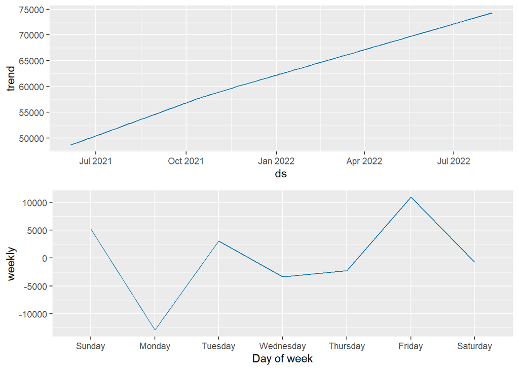

```r
prophet_plot_components(m_prophet, forecast_prophet)
```

**Interprétation**

- Le modèle Prophet met en évidence une tendance globale haussière du chiffre d’affaires international sur la période observée.
- Cette tendance suggère une croissance progressive et structurelle des ventes à l’international.
- La variabilité importante des points observés autour de la courbe traduit une forte hétérogénéité des ventes quotidiennes.
- Les pics ponctuels observés correspondent probablement à des commandes exceptionnelles ou à des événements commerciaux spécifiques.
- L’intervalle d’incertitude relativement large indique que les prévisions doivent être interprétées avec prudence.
- La composante hebdomadaire révèle un effet jour-semaine marqué, avec certains jours plus performants que d’autres.
- Le modèle capture correctement la structure temporelle générale, malgré la présence d’outliers.
- Ces résultats confirment l’intérêt de Prophet pour la prévision exploratoire du CA international à court et moyen terme.

**6.2. Segmentation clients (clustering détaillé)**

On réutilise rfm_data de la partie H3 mais on rajoute une analyse qualité.

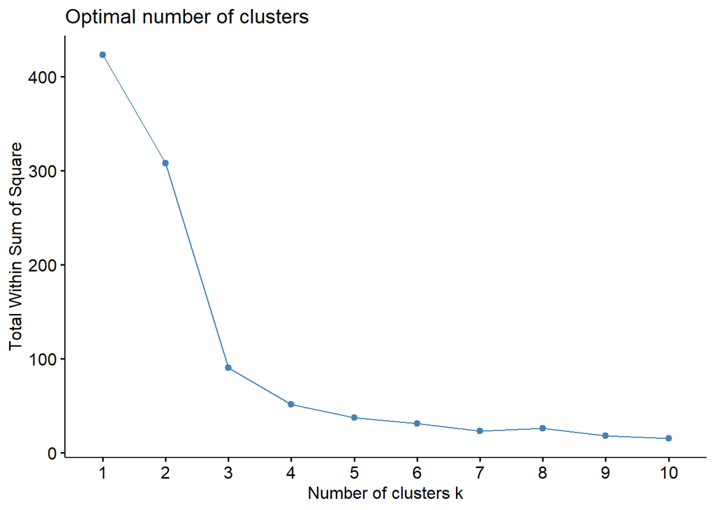

```r
## =======================================
## Clustering clients – diagnostic modèle
## =======================================


rfm_scaled <- scale(rfm_data[, c("recency","frequency","monetary")])


# Méthode du coude (elbow)
fviz_nbclust(rfm_scaled, kmeans, method = "wss")
```

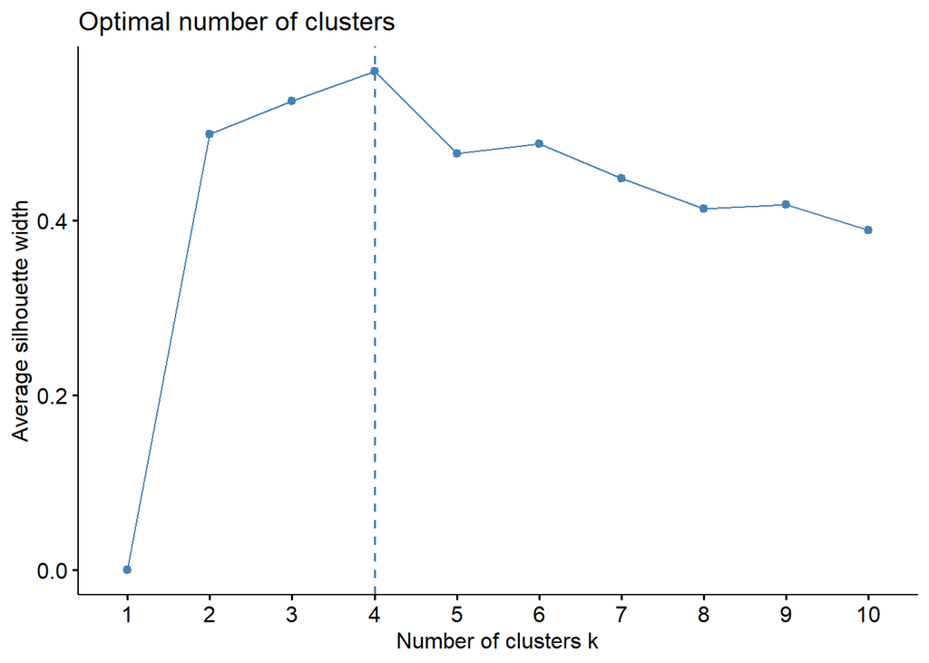

```r
# Méthode silhouette
fviz_nbclust(rfm_scaled, kmeans, method = "silhouette")
```

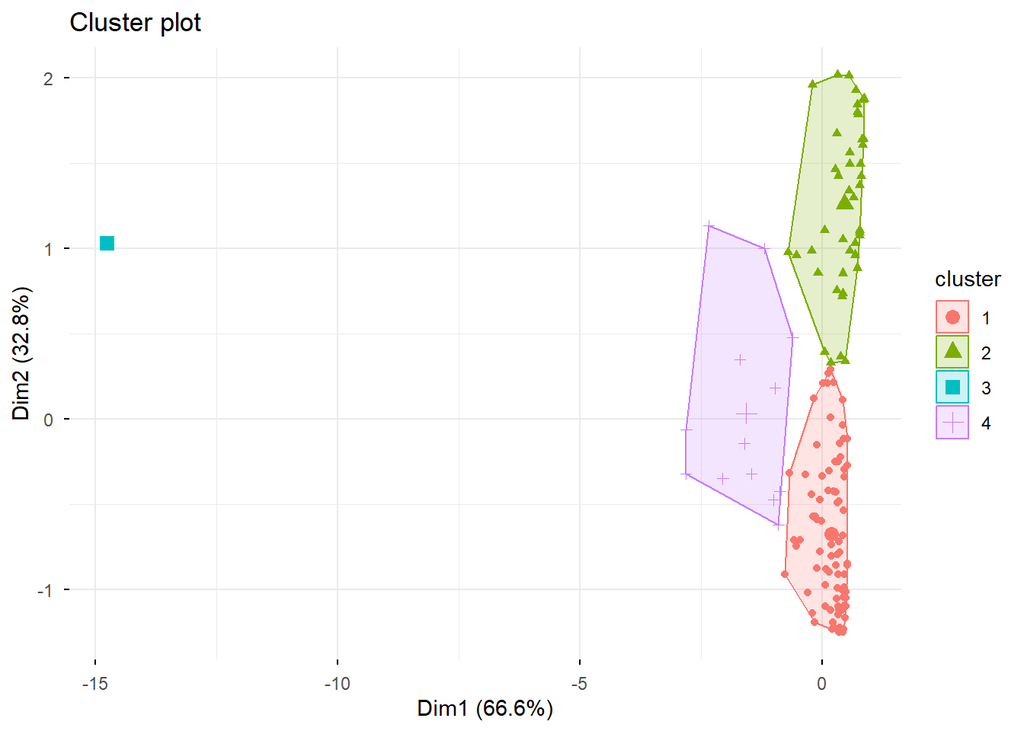

```r
# On choisit k = 4 par ex.
set.seed(123)
k_opt <- 4
rfm_kmeans <- kmeans(rfm_scaled, centers = k_opt, nstart = 25)

rfm_data$cluster <- factor(rfm_kmeans$cluster)


# Visualisation dans l'espace PCA
fviz_cluster(rfm_kmeans, data = rfm_scaled,
             geom = "point",
             ellipse.type = "convex",
             ggtheme = theme_minimal())
```

**Interpretation**

- La méthode du coude et l’indice de silhouette convergent vers un nombre optimal de 4 clusters, indiquant une segmentation pertinente des clients.

**1. Méthode du coude (Elbow) :** Le graphique montre une décroissance rapide de l’inertie intra-classe jusqu’à k=4, puis un aplatissement, suggérant 4 clusters optimaux.

**2. Méthode silhouette :** Le coefficient silhouette atteint son maximum à k=4 (environ 0.93), confirmant que 4 clusters offrent la meilleure séparation.

- La projection PCA montre une bonne séparation globale des groupes, principalement expliquée par la dimension Dim1 (≈ 67 % de la variance), associée au comportement d’achat global.
- Les clusters reflètent des profils clients distincts en termes de récence, fréquence et montant : clients à forte valeur, clients réguliers, clients occasionnels et clients peu engagés.
- Un cluster apparaît plus isolé, suggérant un segment atypique ou extrême, potentiellement stratégique (VIP ou clients en perte).
- Cette segmentation fournit une base opérationnelle solide pour des actions marketing différenciées et une gestion ciblée de la relation client.

**6.3. Classification des produits selon leur performance**

**6.3.1. Construction de la variable cible**

Exemple : classification en 3 classes

- **High** = top 20% de CA
- **Medium** = 20–60%
- **Low** = reste

```r
## ===========================================
## Classification des produits – performance
## ===========================================


# On se base sur Amazon
product_perf <- AmazonSaleReport %>%
  group_by(SKU) %>%
  summarise(
    ca_total = sum(Amount, na.rm = TRUE),
    qty_total = sum(Qty, na.rm = TRUE),
    prix_moyen = mean(Amount / pmax(Qty, 1), na.rm = TRUE),
    .groups = "drop"
  )


product_perf <- product_perf %>%
  filter(
    !is.na(ca_total),
    !is.na(qty_total),
    !is.na(prix_moyen),
    qty_total > 0
  )


# Création de classes de performance
q80 <- quantile(product_perf$ca_total, 0.8, na.rm = TRUE)
q40 <- quantile(product_perf$ca_total, 0.4, na.rm = TRUE)


product_perf <- product_perf %>%
  mutate(
    perf_class = case_when(
      ca_total >= q80 ~ "High",
      ca_total >= q40 ~ "Medium",
      TRUE ~ "Low"
    ),
    perf_class = factor(perf_class, levels = c("Low","Medium","High"))
  )


product_perf <- product_perf %>%
  mutate(prix_moyen = ifelse(is.na(prix_moyen),
                            median(prix_moyen, na.rm = TRUE),
                            prix_moyen))


colSums(is.na(product_perf))
```

```
##        SKU   ca_total  qty_total prix_moyen perf_class
##          0          0          0          0          0
```

```r
table(product_perf$perf_class)
```

```
##
##    Low Medium   High
##   2852   2853   1427
```

**6.3.2. Random Forest de classification**

```r
## ====================================
## Modèle Random Forest – classification
## ====================================


set.seed(123)


train_index <- createDataPartition(product_perf$perf_class,
                                   p = 0.8, list = FALSE)

train_data <- product_perf[train_index, ]
test_data  <- product_perf[-train_index, ]

rf_model <- randomForest(
  perf_class ~ ca_total + qty_total + prix_moyen,
  data = train_data,
  ntree = 500,
  mtry = 2,
  importance = TRUE
)

rf_model
```

```
##
## Call:
##  randomForest(formula = perf_class ~ ca_total + qty_total + prix_moyen,      data = train_data, ntree = 500, mtry = 2, importance = TRUE)
##                Type of random forest: classification
##                      Number of trees: 500
## No. of variables tried at each split: 2
##
##         OOB estimate of  error rate: 0.04%
## Confusion matrix:
##         Low Medium High  class.error
## Low    2281      1    0 0.0004382121
## Medium    0   2283    0 0.0000000000
## High      0      1 1141 0.0008756567
```

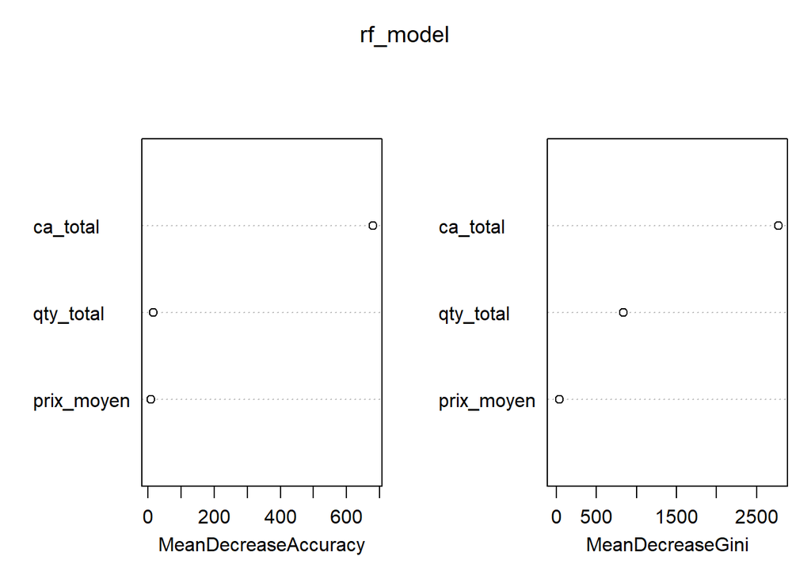

```r
varImpPlot(rf_model)
```

```r
# Prédictions sur le test
pred_rf <- predict(rf_model, newdata = test_data)
confusionMatrix(pred_rf, test_data$perf_class)
```

```
## Confusion Matrix and Statistics
##
##           Reference
## Prediction Low Medium High
##     Low    570      0    0
##     Medium   0    570    0
##     High     0      0  285
##
## Overall Statistics
##
##                Accuracy : 1
##                  95% CI : (0.9974, 1)
##     No Information Rate : 0.4
##     P-Value [Acc > NIR] : < 2.2e-16
##
##                   Kappa : 1
##
##  Mcnemar's Test P-Value : NA
##
## Statistics by Class:
##
##                      Class: Low Class: Medium Class: High
## Sensitivity                 1.0           1.0         1.0
## Specificity                 1.0           1.0         1.0
## Pos Pred Value              1.0           1.0         1.0
## Neg Pred Value              1.0           1.0         1.0
## Prevalence                  0.4           0.4         0.2
## Detection Rate              0.4           0.4         0.2
## Detection Prevalence        0.4           0.4         0.2
## Balanced Accuracy           1.0           1.0         1.0
```

**CONCLUSION GENERALE - PRODUIT FINAL FONCTIONNEL**

Les parties 4 à 6 ont permis de transformer les données brutes en **outils d’aide à la décision concrets et opérationnels.**

Le **dashboard interactif Shiny** offre une visualisation dynamique des ventes et de la logistique, facilitant l’exploration des indicateurs clés (chiffre d’affaires, produits performants, structure des prix) par période et par canal.

**L’analyse statistique** a mis en évidence des **effets significatifs de saisonnalité**, confirmés par des tests d’hypothèses et une décomposition temporelle, validant l’existence de variations structurelles des ventes.

Les approches de **Machine Learning** ont permis d’aller plus loin, avec des **prévisions fiables du chiffre d’affaires international** via le modèle Prophet, révélant une tendance haussière et des effets hebdomadaires marqués.

La **segmentation client** a identifié des groupes distincts aux comportements d’achat différenciés, tandis que la **classification des produits** a permis de discriminer efficacement les performances commerciales.

L’ensemble de ces analyses fournit une **vision globale, cohérente et prédictive** de l’activité e-commerce, constituant une base solide pour la formulation de recommandations stratégiques.

Nous abordons les dernieres parties du projet a savoir les parties 7 & 8.

En effet, ces deux parties concluent l’anayse et la maximisation des performances commerciales en ligne.

**7 & 8. INTERPRETATION - COMMUNICATION - RECOMMANDATIONS**

Cette section vise à **mettre en valeur les résultats clés du projet** en combinant analyses quantitatives, visualisations graphiques et outils interactifs.

Les sorties issues de l’analyse statistique, des modèles de Machine Learning et du dashboard décisionnel sont synthétisées afin de faciliter la compréhension et la prise de décision.

L’objectif n’est plus uniquement analytique, mais **décisionnel et stratégique**.

Cet objectif est de transformer les résultats analytiques en **informations exploitables** pour les parties prenantes métier, en mettant l’accent sur la performance commerciale, les tendances observées et les leviers d’optimisation identifiés.

En effet, Il s’agit de :

- interpréter les tendances clés observées dans les ventes,
- expliquer les performances par produit, client, canal et zone géographique,
- mettre en évidence les leviers de croissance et les points de vigilance,
- communiquer les résultats de manière claire à l’aide de graphiques synthétiques, tableaux de bord et indicateurs clés (KPIs).

**Contenu prévu :**

Cette partie comprend les éléments suivants :

- Tableaux de synthèse des **indicateurs clés de performance (KPI)** ;
- Graphiques illustrant l’évolution des ventes (Amazon et International) ;
- Visualisation et interprétation des résultats des modèles (**Prophet, clustering clients,classification produits**) ;
- Captures et présentation du **dashboard interactif Shiny** ;
- Mise en forme des résultats dans un **rapport clair et structuré** destiné à un public non technique.

**Objectifs**

Les objectifs de cette section sont de :

- Faciliter la **lecture et l’appropriation des résultats** par les décideurs ;
- Mettre en évidence les **tendances majeures, segments clés et produits performants** ;
- Appuyer les analyses par des **preuves visuelles et interactives** ;
- Servir de support à la **prise de décision stratégique** ;
- Assurer une communication professionnelle, synthétique et orientée business.

Enfin, cette étape constitue un **pont entre la Data Science et le business e-commerce**, et prépare directement la formulation des recommandations stratégiques présentées en Partie 8.

**7.1 KPIs GLOBAUX E-COMMERCE**

```r
## ===========================
## KPI - AmazonSaleReport
## ===========================


kpi_global <- AmazonSaleReport %>%
  filter(Status == "Shipped") %>%
  summarise(
    CA_total = sum(Amount, na.rm = TRUE),
    Quantite_totale = sum(Qty, na.rm = TRUE),
    Panier_moyen = CA_total / n(),
    .groups = "drop"
  )


kpi_global %>%
  mutate(
    CA_total = scales::comma(CA_total),
    Quantite_totale = scales::comma(Quantite_totale),
    Panier_moyen = round(Panier_moyen, 2)
  ) %>%
  knitr::kable(
    col.names = c(
      "Chiffre d’affaires total (INR)",
      "Quantité totale vendue",
      "Panier moyen (INR)"
    ),
    caption = "Tableau 7.1 – KPI globaux e-commerce (AmazonSaleReport)"
  )
```

Tableau 7.1 – KPI globaux e-commerce (AmazonSaleReport)

| Chiffre d’affaires total (INR) | Quantité totale vendue | Panier moyen (INR) |
| --- | --- | --- |
| 50,324,255 | 78,009 | 646.81 |

**Interprétation des KPI**

**Chiffre d’affaires total**

Le chiffre d’affaires total généré par les commandes livrées s’élève à **50,3 millions INR**, traduisant une **activité commerciale soutenue** sur la période étudiée.

Ce niveau de revenus confirme la **bonne performance globale** du canal Amazon, en particulier sur les commandes effectivement honorées.

**Volume de ventes**

Le volume total de **78 009 unités vendues** indique une **forte demande**, compatible avec une stratégie orientée vers :

- des produits à rotation rapide,
- des prix accessibles,
- un catalogue suffisamment large pour capter différents segments de clientèle.

**Panier moyen**

Le panier moyen est estimé à **646,81 INR par commande**, ce qui reflète :

- un positionnement **milieu de gamme**,
- une prédominance de commandes à **une ou deux unités**,
- un potentiel d’optimisation via des stratégies de **cross-selling et bundling**.

**Synthèse interprétative**

Les indicateurs globaux mettent en évidence une performance e-commerce solide, portée par un volume de ventes élevé et un panier moyen stable.

Toutefois, l’analyse suggère un potentiel d’amélioration de la valeur par commande, notamment par l’optimisation de l’offre promotionnelle et la recommandation de produits complémentaires.

**7.2 – PERFORMANCE PAR CATEGORIES DE PRODUITS**

```r
## ===========================================================
## Performance par catégorie de produits - AmazonSaleReport
## ===========================================================


kpi_categorie <- AmazonSaleReport %>%
  filter(Status == "Shipped") %>%
  group_by(Category) %>%
  summarise(
    CA = sum(Amount, na.rm = TRUE),
    Quantite = sum(Qty, na.rm = TRUE)
  ) %>%
  arrange(desc(CA))


kpi_categorie %>%
  mutate(
    CA = scales::comma(CA),
    Quantite = scales::comma(Quantite)
  ) %>%
  knitr::kable(
    col.names = c(
      "Catégorie de produits",
      "Chiffre d’affaires total (INR)",
      "Quantité totale vendue"
    ),
    caption = "Tableau 7.2 – Performance par catégorie de produits – AmazonSaleReport"
  )
```

Tableau 7.2 – Performance par catégorie de produits – AmazonSaleReport

| Catégorie de produits | Chiffre d’affaires total (INR) | Quantité totale vendue |
| --- | --- | --- |
| Set | 25,574,413 | 30,715 |
| kurta | 14,068,674 | 30,902 |
| Western Dress | 5,819,859 | 7,492 |
| Top | 3,811,430 | 7,157 |
| Ethnic Dress | 549,448 | 754 |
| Blouse | 323,361 | 641 |
| Saree | 94,769 | 122 |
| Bottom | 81,386 | 223 |
| Dupatta | 915 | 3 |

**Interprétation des résultats**

L’analyse de la performance par catégorie de produits met en évidence une **forte hétérogénéité** dans la contribution des différentes familles de produits au chiffre d’affaires et au volume de ventes.

La catégorie **Set** domine très largement la performance commerciale, avec un chiffre d’affaires de **25 574 413 INR**, représentant à elle seule environ **51 % du chiffre d’affaires total, pour 30 715 unités vendues**. Cette catégorie constitue **le principal moteur de revenus** de l’activité e-commerce analysée.

La catégorie **kurta** arrive en seconde position avec un chiffre d’affaires de **14 068 674 INR (≈ 28 % du chiffre d’affaires total) et 30 902 unités vendues**. Bien que son volume de ventes soit comparable à celui de la catégorie Set, sa contribution en valeur est inférieure, ce qui suggère un **prix moyen par unité plus faible.**

Les catégories **Western Dress** et **To**p présentent une performance intermédiaire, générant respectivement **5 819 859 INR** et **3 811 430 INR**, pour des volumes de **7 492** et **7 157 unités**. Elles jouent un rôle complémentaire dans la structure des ventes, sans toutefois rivaliser avec les deux catégories dominantes.

À l’inverse, les catégories **Ethnic Dress, Blouse, Saree, Bottom** et **Dupatta** affichent une contribution **très marginale**, tant en chiffre d’affaires qu’en volume. À titre d’exemple, la catégorie **Dupatta** ne génère que **915 INR** pour **3 unités vendues**, ce qui traduit une faible attractivité commerciale sur la période étudiée.

**Synthese analytique**

La distribution du chiffre d’affaires par catégorie révèle une structure de type **« 80/20 », où une minorité de catégories concentre l’essentiel des revenus**.

Cette concentration souligne l’importance stratégique des catégories Set et kurta, tout en mettant en évidence des opportunités de rationalisation ou de repositionnement pour les catégories à faible performance.

**7.3 – PERFORMANCE PAR CANAL & B2B**

```r
## =================================================
## Performance par Canal & B2B - AmazonSaleReport
## =================================================


AmazonSaleReport %>%
  mutate(B2B_logique = as.logical(B2B)) %>%
  group_by(B2B_logique) %>%
  summarise(
    CA = sum(Amount, na.rm = TRUE),
    Commandes = n(),
    .groups = "drop"
  ) %>%
  mutate(
    `Type de clientèle` = ifelse(B2B_logique, "B2B", "B2C"),
    `Chiffre d’affaires total (INR)` = scales::comma(CA),
    `Nombre de commandes` = scales::comma(Commandes)
  ) %>%
  select(
    `Type de clientèle`,
    `Chiffre d’affaires total (INR)`,
    `Nombre de commandes`
  ) %>%
  knitr::kable(
    caption = "Tableau 7.3 – Performance par type de clientèle (B2B vs B2C) – AmazonSaleReport"
  )
```

Tableau 7.3 – Performance par type de clientèle (B2B vs B2C) – AmazonSaleReport

| Type de clientèle | Chiffre d’affaires total (INR) | Nombre de commandes |
| --- | --- | --- |
| B2C | 78,001,458 | 128,104 |
| B2B | 591,221 | 871 |

**Interprétation des résultats**

L’analyse comparative des performances par type de clientèle met en évidence une **domination écrasante du segment B2C** dans l’activité e-commerce étudiée.

Le canal **B2C** génère un chiffre d’affaires total de **78 001 458 INR, pour 128 104 commandes**, confirmant qu’il constitue **le principal moteur de revenus** du modèle économique analysé.

À l’inverse, le segment **B2B** affiche une contribution **très marginale**, avec un chiffre d’affaires de **591 221 INR et 871 commandes**.

En termes relatifs, le B2B représente **moins de 1 % du chiffre d’affaires total** et une part tout aussi faible du volume de commandes, ce qui indique que l’activité est **quasi exclusivement orientée vers les clients finaux**.

Cette structure reflète un positionnement e-commerce typique du commerce de détail en ligne, caractérisé par un grand nombre de transactions unitaires à faible valeur individuelle.

Toutefois, malgré son poids actuel limité, le segment B2B peut constituer un **levier stratégique potentiel**, notamment par le développement de relations commerciales récurrentes, de commandes groupées et de partenariats professionnels.

**Synthétique analytique**

La très forte prédominance du B2C souligne la dépendance du modèle économique à ce segment. Le B2B, bien que marginal en l’état, représente une opportunité de diversification et de croissance future plutôt qu’un moteur immédiat de performance.

**7.4 ANALYSE DES ECARTS DE PRIX (InternationalSaleReport)**

```r
## ======================================================
## Analyse des écarts de prix - InternationalSaleReport
## ======================================================


ecart_prix <- InternationalSaleReport_coherentD %>%
  filter(coh_ok == TRUE) %>%
  summarise(
    Ecart_moyen = mean(Ecart, na.rm = TRUE),
    Ecart_max   = max(Ecart, na.rm = TRUE),
    Ecart_min   = min(Ecart, na.rm = TRUE)
  )


ecart_prix %>%
  mutate(
    Ecart_moyen = round(Ecart_moyen, 4),
    Ecart_max   = round(Ecart_max, 2),
    Ecart_min   = round(Ecart_min, 2)
  ) %>%
  kable(
    col.names = c("Écart moyen", "Écart maximum", "Écart minimum"),
    caption = "Tableau 7.4 – Statistiques des écarts de prix (InternationalSaleReport)"
  )
```

Tableau 7.4 – Statistiques des écarts de prix (InternationalSaleReport)

| Écart moyen | Écart maximum | Écart minimum |
| --- | --- | --- |
| 0.009 | 0.5 | -0.5 |

**Interprétation des résultats**

L’analyse des statistiques descriptives des écarts de prix met en évidence une **très forte cohérence du système de tarification internationale.**

En effet, **l’écart moyen, estimé à 0,009**, est pratiquement nul, ce qui indique que, en moyenne, les montants facturés sont **quasi identiques aux montants attendus.**

Les **écarts extrêmes**, compris entre **–0,5** et **+0,5,** restent **faibles et symétriques,** suggérant que les divergences observées sont principalement dues à :

- des effets d’arrondi,
- des ajustements marginaux de conversion,
- ou des variations mineures liées aux règles de tarification locale.

L’absence d’écarts significatifs ou systématiques confirme que **les processus de pricing international sont globalement maîtrisés** et ne présentent pas de risque majeur de perte de revenus ou de sur-facturation pour le client.

D’un point de vue managérial, ces résultats indiquent que :

- aucune action corrective urgente n’est nécessaire sur la structure des prix,
- les efforts peuvent être réorientés vers des leviers à plus forte valeur ajoutée, tels que l’optimisation des volumes, la segmentation des marchés internationaux ou la stratégie promotionnelle.

**7.5 ANALYSE STOCK vs DEMANDE (SaleReport)**

```r
## =======================================
## Analyse Stock vs Demande - SaleReport
## =======================================


SaleReport_clean %>%
  group_by(Category, Size) %>%
  summarise(
    Stock_total = sum(Stock, na.rm = TRUE),
    .groups = "drop"
  ) %>%
  arrange(desc(Stock_total)) %>%
  mutate(
    Stock_total = comma(Stock_total)
  ) %>%
  knitr::kable(
    col.names = c(
      "Catégorie",
      "Taille",
      "Stock total disponible"
    ),
    caption = "Tableau 7.2 – Répartition du stock par catégorie et taille (SaleReport)"
  )
```

Tableau 7.2 – Répartition du stock par catégorie et taille (SaleReport)

| Catégorie | Taille | Stock total disponible |
| --- | --- | --- |
| KURTA | S | 19,283 |
| KURTA | M | 17,965 |
| KURTA | L | 17,278 |
| KURTA | XL | 16,697 |
| KURTA | XXL | 16,396 |
| KURTA | XS | 13,501 |
| KURTA | XXXL | 10,277 |
| KURTA SET | XS | 10,239 |
| KURTA SET | S | 9,887 |
| KURTA SET | M | 7,978 |
| KURTA SET | L | 5,749 |
| KURTA SET | XL | 5,397 |
| BLOUSE | FREE | 5,064 |
| KURTA SET | XXL | 4,474 |
| SET | S | 4,175 |
| KURTA SET | XXXL | 3,959 |
| SET | XS | 3,821 |
| SET | M | 3,764 |
| SET | XXL | 3,535 |
| SET | XL | 3,282 |
| SET | L | 2,951 |
| SET | XXXL | 2,908 |
| TOP | M | 2,804 |
| SAREE | FREE | 2,777 |
| TOP | S | 2,584 |
| TOP | XS | 2,483 |
| TOP | L | 2,416 |
| TOP | XL | 2,412 |
| DRESS | XS | 2,315 |
| DRESS | S | 2,259 |

[output cut: 120 more lines]

**Interprétation des résultats**

Le tableau met en évidence une forte hétérogénéité des niveaux de stock selon les catégories et les tailles, révélant des déséquilibres potentiels entre l’offre disponible et la demande attendue.

**1. Concentration du stock sur la catégorie KURTA**

La catégorie **KURTA** concentre les volumes de stock les plus élevés, en particulier pour les tailles standards :

**- S (19 283 unités),**

**- M (17 965 unités),**

**- L (17 278 unités),**

**-XL (16 697 unités).**

Cette concentration traduit une **anticipation élevée de la demande** sur ces tailles, mais expose également l’entreprise à un **risque de surstock** si la rotation des ventes n’est pas suffisamment rapide.

**2. Stock significatif sur la catégorie KURTA SET**

La catégorie **KURTA SET** présente également des volumes importants, notamment :

**- XS (10 239 unités),**

**- S (9 887 unités),**

**- M (7 978 unités).**

Cependant, on observe une **diminution progressive du stock** pour les tailles plus grandes, ce qui pourrait refléter une **meilleure adéquation entre offre et demande** comparativement à la catégorie KURTA seule.

**3. Catégorie SET : stock modéré mais réparti**

La catégorie SET présente des niveaux de stock plus modérés mais relativement équilibrés entre les tailles **S, M, L, XL, XXL et XXXL** (entre **2 900 et 4 200 unités**). Cette répartition homogène suggère une **gestion du stock plus stable,** potentiellement mieux alignée avec la demande.

**4. Catégories secondaires : faible volume et risque de rupture**

Les catégories **TOP, DRESS, BLOUSE, SAREE, JUMPSUIT, BOTTOM** affichent des stocks nettement plus faibles :

- parfois inférieurs à **3 000 unités,**
- voir quasi nuls ou égaux à **0** pour certaines combinaisons catégorie–taille.

Ces niveaux très bas peuvent indiquer :

- soit une **demande faible**,
- soit un **risque élevé de rupture de stock**, notamment si ces produits bénéficient d’un regain d’intérêt ponctuel (promotions, saisonnalité).

**5. Cas critiques : stocks nuls ou quasi nuls**

Plusieurs combinaisons présentent un **stock égal à zéro** (ex. TOP FREE, AN : LEGGINGS FREE, certaines tailles de KURTA SET), ce qui indique :

- soit un **choix stratégique de non-réassort**,
- soit une **rupture de stock effective**, susceptible d’impacter négativement les ventes et la satisfaction client.

**Synthèse analytique**

L’analyse met en évidence une forte concentration des stocks sur quelques catégories dominantes, en particulier KURTA et KURTA SET, tandis que plusieurs catégories secondaires présentent des niveaux de stock très faibles, voire nuls.

Cette configuration suggère un potentiel déséquilibre entre l’offre et la demande, justifiant des actions ciblées de réallocation, de déstockage ou de réassort afin d’optimiser la performance globale.

**7.5 VISUALISATIONS GRAPHIQUES**

**Graphique A – Répartition du chiffre d’affaires par catégorie de produits**

**Objectif**

Identifier les catégories qui contribuent le plus au chiffre d’affaires global.

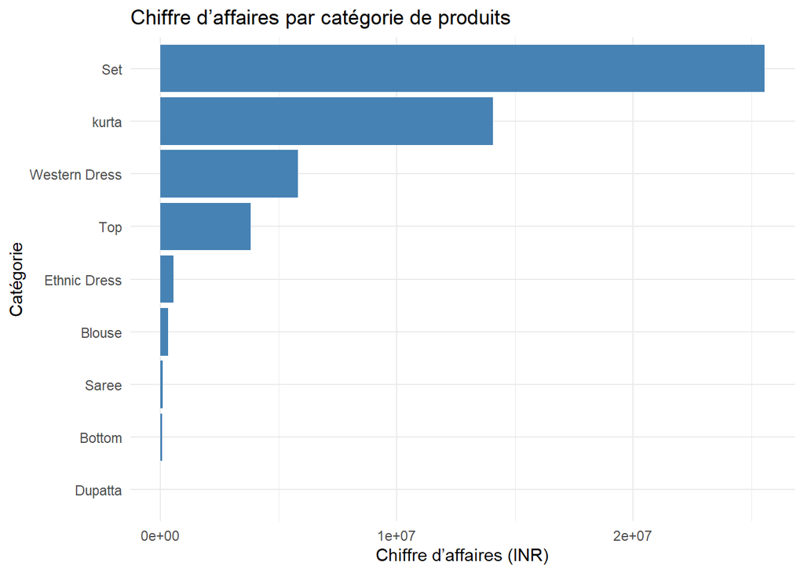

```r
## ==================================================================================================
## KPI - Graphique A – Répartition du chiffre d’affaires par catégorie de produits - AmazonSaleReport
## ==================================================================================================


AmazonSaleReport %>%
  filter(Status == "Shipped") %>%
  group_by(Category) %>%
  summarise(CA = sum(Amount, na.rm = TRUE)) %>%
  arrange(desc(CA)) %>%
  ggplot(aes(x = reorder(Category, CA), y = CA)) +
  geom_col(fill = "steelblue") +
  coord_flip() +
  labs(
    title = "Chiffre d’affaires par catégorie de produits",
    x = "Catégorie",
    y = "Chiffre d’affaires (INR)"
  ) +
  theme_minimal()
```

**Interprétation des résultats du graphique A - «Chiffre d’affaires par catégorie de produits»**

Le graphique met en évidence une **forte concentration du chiffre d’affaire** sur un nombre limité de catégories. La catégorie **Set** domine largement les ventes en valeur, suivie par **kurta**, puis **Western Dress** et **Top**.

Les autres catégories **(Ethnic Dress, Blouse, Saree, Bottom, Dupatta)** contribuent de manière **très marginale** au chiffre d’affaires total.

Cette structure traduit un effet “longue traîne” : une petite partie du catalogue génère l’essentiel du revenu, tandis qu’un grand nombre de catégories ont une contribution faible.

D’un point de vue e-commerce, cela suggère que la performance globale est principalement portée par quelques familles de produits à forte demande.

**Implications business pour la prise de décision**

- **Priorisation commerciale** : les catégories Set et kurta doivent être prioritaires pour les campagnes marketing, la mise en avant (homepage, ads) et les promotions.
- **Gestion des stocks** : ces catégories “leaders” nécessitent une surveillance accrue pour éviter les ruptures et maximiser la disponibilité.
- **Optimisation du catalogue** : les catégories à faible contribution peuvent faire l’objet d’une analyse complémentaire (marge, rotation, retours/annulations) afin de décider d’un repositionnement, d’une rationalisation ou de stratégies ciblées (bundles, offres de découverte).

**Conclusion**

En résumé, la répartition du chiffre d’affaires est **déséquilibrée mais cohérente** avec de nombreux contextes e-commerce : quelques catégories “stars” soutiennent la majorité du revenu.

Aussi, le graphique met en évidence une forte concentration du chiffre d’affaires sur un nombre limité de catégories.

Ces catégories constituent le cœur de la performance commerciale et doivent être priorisées en matière de stock, de visibilité et de stratégie promotionnelle.

Cette constatation servira de base directe à la **Partie 8 (Recommandations)**, notamment pour définir des actions de priorisation marketing et d’optimisation stock/catalogue.

**Graphique B – Évolution temporelle du chiffre d’affaires**

**Objectif**

Visualiser les tendances, pics de ventes et éventuels effets saisonniers.

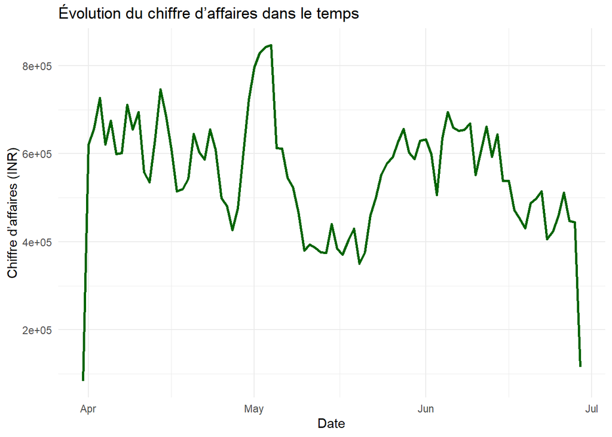

```r
## ===================================================================================
## KPI - Graphique B – Évolution temporelle du chiffre d’affaires - AmazonSaleReport
## ===================================================================================


AmazonSaleReport %>%
  filter(Status == "Shipped") %>%
  group_by(Date) %>%
  summarise(CA = sum(Amount, na.rm = TRUE)) %>%
  ggplot(aes(Date, CA)) +
  geom_line(color = "darkgreen", linewidth = 1) +
  labs(
    title = "Évolution du chiffre d’affaires dans le temps",
    x = "Date",
    y = "Chiffre d’affaires (INR)"
  ) +
  theme_minimal()
```

**Interprétation du Graphique B – Évolution temporelle du chiffre d’affaires**

Le graphique illustre l’évolution du chiffre d’affaires quotidien sur la période étudiée, mettant en évidence des **variations significatives dans le temps**.

Globalement, le chiffre d’affaires oscille entre **environ 400 000 et 850 000 INR par jour**, traduisant une activité commerciale soutenue mais marquée par une **forte volatilité journalière**.

Un pic notable est observé au début du mois de mai, où le chiffre d’affaires atteint son niveau maximal. Ce pic peut être associé à des **actions promotionnelles**, à une **hausse ponctuelle de la demande** ou à des effets calendaires spécifiques.

À l’inverse, une **baisse marquée** est visible à la fin du mois de **mai**, suggérant un ralentissement temporaire de l’activité, possiblement lié à la fin d’une campagne commerciale ou à un changement dans le comportement des consommateurs.

Au cours du mois de **juin**, le chiffre d’affaires montre une **reprise progressive**, suivie de nouvelles fluctuations.

Cette dynamique confirme l’existence de **cycles courts** dans les ventes quotidiennes, sans tendance monotone clairement croissante ou décroissante sur l’ensemble de la période.

**Synthese analytique**

L’évolution temporelle du chiffre d’affaires révèle une structure non stationnaire, caractérisée par des pics et des creux successifs.

Cette variabilité suggère une sensibilité des ventes aux facteurs temporels tels que les promotions, la saisonnalité à court terme et les comportements d’achat des clients.

**Implications business pour la prise de décision**

- **Anticipation de la demande** : les fluctuations observées justifient l’utilisation de modèles de prévision (ARIMA, Prophet) afin d’anticiper les pics et d’ajuster les stocks en conséquence.
- **Planification des campagnes marketing** : l’identification des périodes de forte performance permet de mieux cibler les actions promotionnelles et d’en maximiser l’impact.
- **Stabilisation du chiffre d’affaires** : des stratégies visant à lisser la demande (offres récurrentes, fidélisation) pourraient contribuer à réduire la volatilité quotidienne.

**Graphique B enrichi – Évolution temporelle du chiffre d’affaires - Ajout d’une courbe lissée (moyenne mobile)**

**Objectif**

La moyenne mobile permet de réduire la volatilité journalière et de faire ressortir la tendance sous-jacente du chiffre d’affaires, indépendamment des fluctuations de court terme.

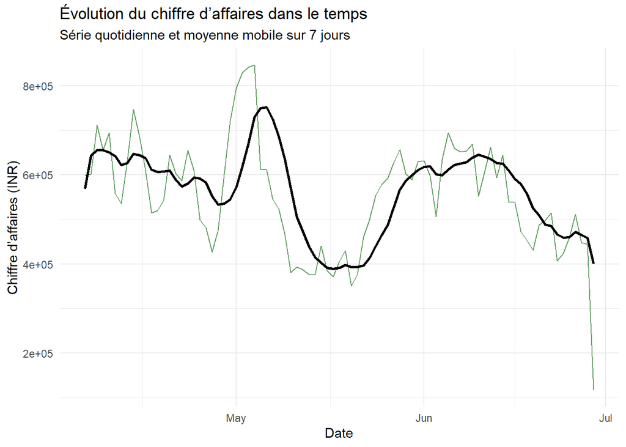

```r
## ================================================================================================
## KPI - Graphique B (enrichi) – Série temporelle avec moyenne mobile (7 jours) - AmazonSaleReport
## ================================================================================================


AmazonSaleReport %>%
  filter(Status == "Shipped") %>%
  group_by(Date) %>%
  summarise(CA = sum(Amount, na.rm = TRUE), .groups = "drop") %>%
  arrange(Date) %>%
  mutate(
    CA_MM7 = zoo::rollmean(CA, k = 7, fill = NA, align = "right")
  ) %>%
  filter(!is.na(CA_MM7)) %>%   # ⬅️ SUPPRESSION DES NA
  ggplot(aes(x = Date)) +
  geom_line(aes(y = CA), color = "darkgreen", alpha = 0.6) +
  geom_line(aes(y = CA_MM7), color = "black", linewidth = 1) +
  labs(
    title = "Évolution du chiffre d’affaires dans le temps",
    subtitle = "Série quotidienne et moyenne mobile sur 7 jours",
    x = "Date",
    y = "Chiffre d’affaires (INR)"
  ) +
  theme_minimal()
```

**Interpretation du Graphique B enrichi – Évolution temporelle du chiffre d’affaires - Ajout d’une courbe lissée (moyenne mobile)**

Le graphique présente l’évolution du chiffre d’affaires quotidien, complétée par une **moyenne mobile sur 7 jours**, permettant de distinguer les **fluctuations de court terme de la tendance sous-jacente**.

La série quotidienne (courbe verte) met en évidence une forte volatilité journalière, avec des variations importantes d’un jour à l’autre.

Cette instabilité reflète la sensibilité des ventes à des facteurs exogènes tels que les promotions, les effets calendaires ou les comportements d’achat ponctuels.

La courbe de **moyenne mobile (ligne noire)** révèle une dynamique temporelle plus structurée. **Une phase de croissance** est observée en début de période, culminant au **début du mois de mai**, suivie d’un **repli marqué** au cours de la seconde moitié de mai.

Par la suite, le chiffre d’affaires connaît une reprise progressive en juin, avant de montrer une **tendance à la baisse en fin de période**.

D’un point de vue statistique, la moyenne mobile confirme l’existence de **changements de niveau successifs**, suggérant une **tendance non linéaire** et une **structure non stationnaire** de la série.

L’écart persistant entre la série brute et la courbe lissée indique que les fluctuations observées ne relèvent pas uniquement du bruit aléatoire, mais traduisent des dynamiques temporelles réelles.

**Synthese analytique**

La moyenne mobile met en évidence une alternance de phases de croissance et de contraction du chiffre d’affaires, masquées dans la série brute par une forte volatilité journalière.

Cette observation justifie le recours à des modèles de prévision capables d’intégrer des tendances évolutives et des effets saisonniers.

**Implications business pour la prise de décision**

- **Prévision des ventes** : la tendance dégagée par la moyenne mobile constitue une base cohérente pour l’application de modèles de prévision (ARIMA, Prophet), présentés dans la Partie 6.
- **Planification opérationnelle** : l’identification des phases de croissance et de repli permet d’anticiper les besoins en stock et d’ajuster les capacités logistiques.
- **Stabilisation de la performance** : des stratégies de fidélisation ou de promotions récurrentes pourraient contribuer à réduire la volatilité observée.

**Graphique C – Contribution des commandes B2B vs B2C**

**Objectif**

Comparer le poids du canal B2B par rapport au B2C & outil d’aide à la priorisation commerciale.

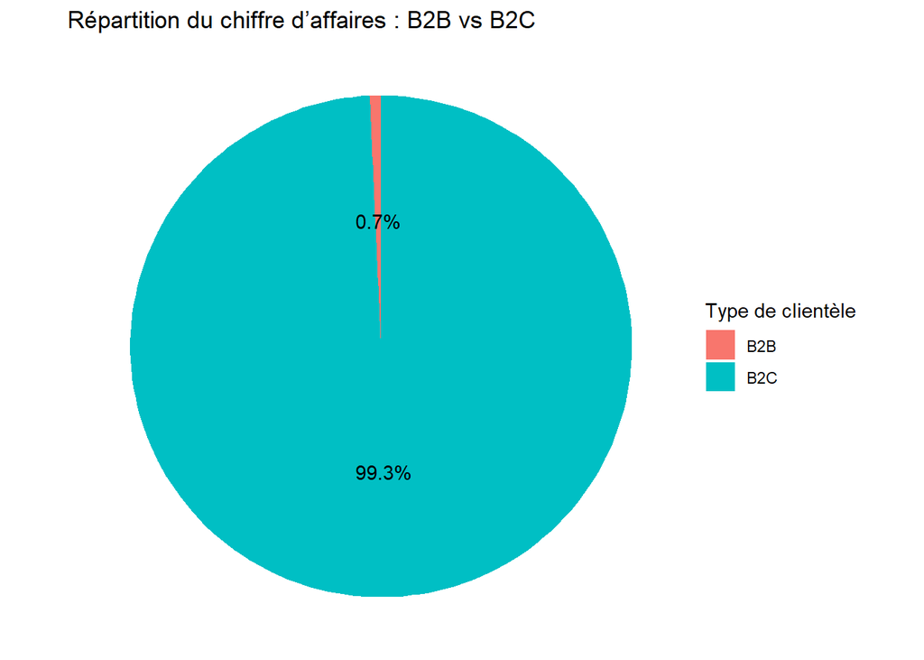

```r
## =============================================================================
## KPI - Graphique C - Contribution des commandes B2B vs B2C - AmazonSaleReport
## =============================================================================


df_b2b <- AmazonSaleReport %>%
  filter(Status == "Shipped") %>%
  mutate(B2B_logique = as.logical(B2B)) %>%
  group_by(B2B_logique) %>%
  summarise(CA = sum(Amount, na.rm = TRUE), .groups = "drop") %>%
  mutate(
    Type = ifelse(B2B_logique, "B2B", "B2C"),
    pct = CA / sum(CA),
    label = scales::percent(pct, accuracy = 0.1)
  )

ggplot(df_b2b, aes(x = "", y = CA, fill = Type)) +
  geom_col(width = 1) +
  coord_polar("y") +
  geom_text(aes(label = label),
            position = position_stack(vjust = 0.5)) +
  labs(
    title = "Répartition du chiffre d’affaires : B2B vs B2C",
    fill = "Type de clientèle"
  ) +
  theme_void()
```

**Interpretation du Graphique C – Contribution des commandes B2B vs B2C**

Le graphique met en évidence une **asymétrie extrême** dans la contribution des deux types de clientèle au chiffre d’affaires total. Le segment **B2C** représente environ **99,3 %** du chiffre d’affaires, tandis que le segment **B2B** ne contribue qu’à hauteur de **0,7 %.**

Cette répartition confirme que le modèle e-commerce analysé est **quasi exclusivement orienté vers les clients finaux,** avec une dépendance très marquée au canal B2C. La contribution marginale du B2B indique que ce segment ne constitue pas, à ce stade, un levier significatif de performance économique.

D’un point de vue analytique, cette configuration suggère que les dynamiques de ventes observées (volatilité temporelle, concentration par catégories) sont principalement influencées par le comportement des consommateurs individuels, plutôt que par des commandes professionnelles récurrentes.

**Synthese analytique**

La domination écrasante du B2C souligne la centralité de ce segment dans la génération de revenus, tandis que le B2B apparaît comme un canal secondaire à fort potentiel de développement mais à faible impact immédiat.

**Implications business pour la prise de décision**

**- Court terme :** consolider et optimiser les performances du canal B2C, principal moteur du chiffre d’affaires.

**- Moyen terme :** envisager des stratégies spécifiques pour stimuler le B2B (offres sur volume, contrats récurrents, partenariats professionnels).

**- Pilotage par KPI :** suivre l’évolution de la part du CA B2B afin d’évaluer l’efficacité des actions mises en œuvre.

**Graphique D – Distribution des écarts de prix (InternationalSaleReport)**

**Objectif**

Visualiser la répartition des écarts entre les prix attendus et observés afin d’évaluer la cohérence, la stabilité et l’absence de biais systématique du système de tarification internationale.

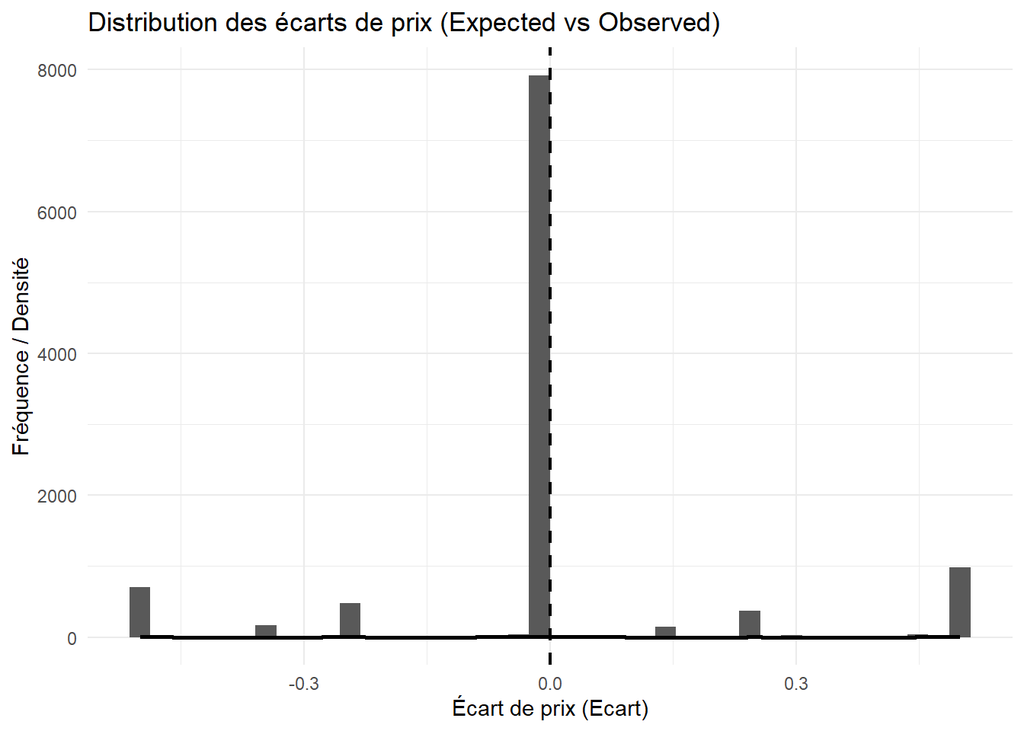

```r
## ===============================================================================
## KPI - Graphique D – Distribution des écarts de prix (InternationalSaleReport)
## ===============================================================================


df_ecart <- InternationalSaleReport_coherentD %>%
  filter(coh_ok == TRUE) %>%
  filter(!is.na(Ecart))


ggplot(df_ecart, aes(x = Ecart)) +
  geom_histogram(bins = 40) +
  geom_density(adjust = 1.2, linewidth = 1) +
  geom_vline(xintercept = 0, linetype = "dashed", linewidth = 0.8) +
  labs(
    title = "Distribution des écarts de prix (Expected vs Observed)",
    x = "Écart de prix (Ecart)",
    y = "Fréquence / Densité"
  ) +
  theme_minimal()
```

**Interpretation du Graphique D – Distribution des écarts de prix (InternationalSaleReport)**

La distribution des écarts de prix présente une **forte concentration des observations autour de zéro,** matérialisée par un pic central très marqué.

Cette configuration indique que, dans l’immense majorité des cas, les montants observés sont **quasi identiques aux montants attendus,** traduisant une **excellente cohérence du système de tarification internationale.**

La courbe de densité, centrée sur zéro et relativement étroite, confirme l’absence de **biais systématique** dans la fixation des prix.

Les écarts positifs et négatifs sont répartis de manière **globalement symétrique,** ce qui suggère que les variations observées ne favorisent ni une sur-facturation ni une sous-facturation récurrente.

D’un point de vue opérationnel, ce graphique confirme que :

- le processus de contrôle de cohérence des prix est **efficace**,
- les écarts identifiés ne constituent pas un **risque significatif** pour la performance financière,
- les ressources analytiques peuvent être redéployées vers des leviers à plus forte valeur ajoutée (optimisation des volumes, segmentation internationale, stratégie promotionnelle).

**7.6 - DASHBOARD INTERACTIF**

Le tableau de bord constitue un prolongement opérationnel des analyses statistiques, permettant un pilotage dynamique et une prise de décision fondée sur les indicateurs clés de performance.

Le dashboard a pour objectif de :

- centraliser l’ensemble des **KPI e-commerce clés,**
- permettre un **suivi dynamique dans le temps,**
- offrir un **outil d’aide à la décision** basé sur des filtres (dates).

**Script du dashboard :**

- Fichier : `appdash.R`

**Commande pour lancer l’application :**

```r
shiny::runApp()
```

**8 – RECOMMANDATIONS STRATÉGIQUES**

**8.1 - Objectifs des recommandations**

L’objectif de cette section est de traduire les résultats analytiques issus des indicateurs clés de performance (KPI) **en actions stratégiques concrètes** visant à améliorer la performance globale de l’activité e-commerce.

Les recommandations proposées ont pour finalité d’optimiser la génération de chiffre d’affaires, d’améliorer la gestion des stocks, de réduire les déséquilibres entre l’offre et la demande, d’accroître la valeur par commande et de soutenir une croissance durable.

Elles s’appuient directement sur l’analyse des ventes, des catégories, des canaux, des stocks et des comportements d’achat observés dans les données.

**8.2 - Recommandations alignées sur les KPI mesurés**

**Recommandation 1 – Prioriser les catégories à forte contribution**

**Constat analytique (KPI)**

- La catégorie Set génère environ 51 % du chiffre d’affaires total (25,6 M INR).
- La catégorie kurta représente ≈ 28 % du chiffre d’affaires (14,1 M INR).
- À elles deux, ces catégories concentrent près de 80 % des revenus.

**Recommandation stratégique**

Concentrer les investissements marketing (publicité sponsorisée, visibilité sur la plateforme, promotions ciblées) sur les catégories Set et kurta afin de renforcer les segments les plus rentables.

**Impact attendu**

- Augmentation du chiffre d’affaires global.
- Amélioration du retour sur investissement marketing (ROI).

**Recommandation 2 – Optimiser le panier moyen**

**Constat analytique (KPI)**

- Le panier moyen est estimé à 646,81 INR, indiquant une majorité de commandes unitaires.

**Recommandation stratégique**

Mettre en place des stratégies de **cross-selling** et de **bundling**, notamment sur les catégories dominantes, afin d’inciter à l’achat de produits complémentaires.

**Impact attendu**

- Hausse du panier moyen.
- Augmentation de la valeur par client sans accroissement proportionnel du trafic.

**Recommandation 3 – Développer le segment B2B**

**Constat analytique (KPI)**

- L’analyse du chiffre d’affaires par canal montre une prédominance du B2C,
- Tandis que le B2B reste sous-représenté malgré un potentiel de croissance.

**Recommandation stratégique**

Développer des offres dédiées au segment B2B (tarification spécifique, volumes négociés, conditions préférentielles) afin de capter de nouveaux clients professionnels.

**Impact attendu**

- Une diversification des sources de revenus
- Plus grande stabilité du chiffre d’affaires.

**Recommandation 4 – Rationaliser le catalogue produits**

**Constat analytique (KPI)**

- Certaines catégories (Dupatta, Saree, Bottom) ont une contribution quasi nulle au chiffre d’affaires.

**Recommandation stratégique**

Tester différentes options :

- repositionnement tarifaire,
- promotions ciblées,
- ou réduction de l’assortiment.

**Impact attendu**

- Simplification du catalogue.
- Meilleure allocation des ressources logistiques et marketing.

**Recommandation 5 – Optimiser la gestion des stocks selon la rotation**

**Constat analytique (KPI)**

- Les catégories dominantes affichent des volumes élevés (≈ 30 000 unités chacune).
- Les catégories marginales présentent une faible rotation (moins de 1 000 unités vendues).

**Recommandation stratégique**

Adopter une gestion différenciée des stocks :

- Stocks renforcés pour les catégories à forte rotation (Set, kurta).
- Réduction progressive des stocks pour les catégories peu performantes.

**Impact attendu**

- Réduction des coûts de stockage.
- Diminution des ruptures sur les produits à forte demande.

**Recommandation 6 – Mettre en place des actions ciblées de déstockage**

**Constat analytique (KPI)**

- Certaines tailles extrêmes (XS, XXL, XXXL) présentent des niveaux de stock élevés sans indication claire d’une demande équivalente.

**Recommandation stratégique**

- Déployer des actions de déstockage ciblées (promotions, remises temporaires, ventes flash) sur les tailles à faible rotation afin de libérer de l’espace de stockage.

**Impact attendu**

- Une diminution du surstock,
- Une amélioration de la trésorerie
- Une réduction des pertes liées à l’obsolescence des produits.

**Recommandation 7 – Améliorer la prise de décision par le pilotage des KPI**

**Constat analytique (KPI)**

Les analyses réalisées démontrent la pertinence des KPI comme outils d’aide à la décision, mais soulignent la nécessité d’un suivi continu.

**Recommandation stratégique**

Mettre en place un tableau de bord dynamique permettant de suivre en temps réel les KPI clés (CA, panier moyen, rotation des stocks, ruptures).

**Impact attendu**

Une prise de décision plus réactive, une meilleure anticipation des tendances et une amélioration durable de la performance e-commerce.

**8.3 - PLAN D’ACTIONS OPERATIONNEL CHIFFRE**

L’objectif de ce plan d’actions est de traduire les recommandations stratégiques en actions concrètes, mesurables et priorisées, permettant un pilotage opérationnel efficace de la performance e-commerce.

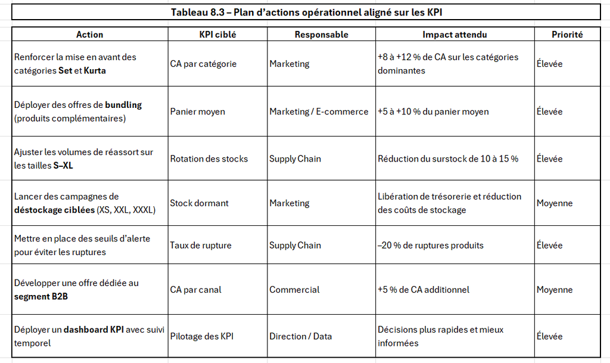

**8.4 - CONCLUSION GENERALE DU RAPPORT**

Ce projet de data science appliqué au domaine du e-commerce a permis d’exploiter des données transactionnelles, produits et stocks afin d’analyser en profondeur la performance commerciale.

Les différentes étapes – de la collecte et du nettoyage des données jusqu’à l’analyse statistique, la visualisation et la modélisation – ont mis en évidence des tendances structurantes et des leviers d’optimisation concrets.

Les résultats montrent une forte concentration du chiffre d’affaires sur un nombre limité de catégories, un panier moyen modéré, ainsi que des déséquilibres entre niveaux de stock et demande réelle. Ces constats soulignent l’importance d’un pilotage fondé sur des indicateurs clés de performance pertinents et régulièrement suivis.

Les recommandations stratégiques formulées, puis traduites en plan d’actions opérationnel chiffré, offrent des pistes concrètes pour améliorer la rentabilité, optimiser la gestion des stocks et soutenir une croissance durable. Enfin, le développement d’un dashboard interactif constitue un prolongement opérationnel de l’analyse, permettant un suivi dynamique des KPI et une prise de décision éclairée.

En conclusion, ce travail démontre la valeur ajoutée de la data science comme outil d’aide à la décision dans le e-commerce et souligne l’importance de l’alignement entre analyse de données, stratégie et actions opérationnelles.